# Offshore pickers on ocean-bottom seismometers

QuakeScope will process ocean-bottom data, and ocean-bottom data is not land data with more noise. The instrument sits under a water column that reverberates, often on soft sediment, with horizontals that are **arbitrarily oriented** because nobody was there to point them north. Most stations also carry a **hydrophone**, a channel that has no land equivalent at all.

SeisBench ships **three** ocean-bottom pickers, and the differences between them are the interesting part:

| Model | Backbone | Components | Hydrophone |
| --- | --- | --- | --- |
| `PickBlue(base="phasenet")` | PhaseNet | `Z12H` | yes |
| `PickBlue(base="eqtransformer")` | EQTransformer | `Z12H` | yes |
| `OBSTransformer` (Niksejel & Zhang, 2024) | EQTransformer | `ZNE` | **no** |

`PickBlue` is a constructor rather than a model — it returns the `obs` weights on whichever backbone you ask for. `OBSTransformer` is the useful control: trained on ocean-bottom data but taking only three components, which separates *trained offshore* from *uses the fourth channel*.

Two land models quantify what running them offshore costs. All five see identical windows on three deployments in contrasting settings.

| Deployment | Network | When | Setting |
| --- | --- | --- | --- |
| **Cascadia Initiative** | 7D | 2012–13 | Subduction margin, offshore northern California |
| **AACSE** | XO | 2018–19 | Alaska Peninsula subduction, shelf to trench |
| **Blanco** | X9 | 2012–13 | Oceanic transform, strike-slip in young crust |

### How sections 5–7 score detection, and why sections 8–11 do it differently

Regional catalogs do not pick temporary OBS deployments, so there are no analyst arrivals at these stations to score against. Instead each catalog event gets a **predicted** P arrival from iasp91, and a model counts as having detected it if it places a P pick within a tolerance of that time.

That prediction is the weak link and the tolerance has to absorb it: iasp91 has no water layer and no sediment column, both of which delay the true arrival relative to the model. Treat the numbers as **relative** between weight sets on identical data, not as absolute detection rates.

Since this was first written, published picks have turned up for two of the three settings. Sections 8–11 use them: the `obs` campaign's stored picks are scored against analyst-checked arrivals on the AACSE array and against the University of Washington's real-time catalogue at Axial Seamount, and the five models above are re-scored on AACSE windows against analyst picks instead of a prediction. Blanco stays as it is - the published picks there are available on request, not for download.

```python
from collections import defaultdict

import matplotlib.pyplot as plt
import numpy as np
import obspy
import pandas as pd
import seisbench.models as sbm
from obspy import UTCDateTime
from obspy.clients.fdsn import Client
from obspy.geodetics import gps2dist_azimuth, locations2degrees
from obspy.taup import TauPyModel

%matplotlib inline
```

## 1. Configuration

```python
# Three deployments, chosen for contrasting settings and instrumentation.
# Stations were selected by confirming all four components actually return
# data, not from metadata - and the hydrophone sampling rate differs by an
# order of magnitude between experiments, which section 6 tests the effect of.
EXPERIMENTS = {
    "Cascadia (7D)": dict(
        network="7D", start=UTCDateTime("2012-09-01"), end=UTCDateTime("2013-05-01"),
        lat=40.3, lon=-124.8, min_mag=3.5, max_radius_deg=2.0,
        stations=[("FS07B", "HH", "HDH"), ("FS06B", "BH", "BDH"), ("FS05B", "BH", "BDH")],
        note="Cascadia subduction margin, offshore northern California",
    ),
    "AACSE (XO)": dict(
        network="XO", start=UTCDateTime("2018-08-01"), end=UTCDateTime("2019-06-01"),
        lat=54.8, lon=-155.5, min_mag=3.5, max_radius_deg=2.0,
        stations=[("LA23", "HH", "EDH"), ("LA25", "HH", "EDH"), ("LD36", "HH", "HDH")],
        note="Alaska Peninsula subduction zone, shelf and trench",
    ),
    "Blanco (X9)": dict(
        network="X9", start=UTCDateTime("2012-10-01"), end=UTCDateTime("2013-08-01"),
        lat=43.1, lon=-126.4, min_mag=3.5, max_radius_deg=2.0,
        stations=[("BB060", "HH", "BDH"), ("BB090", "HH", "BDH"), ("BB070", "HH", "BDH")],
        note="Blanco oceanic transform - strike-slip in young oceanic crust",
    ),
}

# SeisBench ships three ocean-bottom pickers and they differ in ways that
# matter here.
#
#   PickBlue is a constructor, not a model: PickBlue(base=...) returns the
#   "obs" weights on either a PhaseNet or an EQTransformer backbone. Both take
#   four components, Z12H, the last being the hydrophone.
#
#   OBSTransformer (Niksejel & Zhang, 2024) is also OBS-trained but takes only
#   three components - no hydrophone. It is the control that separates
#   "trained on ocean-bottom data" from "uses the fourth channel".
#
# The land models quantify what running them offshore costs.
MODEL_SPECS = {
    "pickblue_phasenet": dict(build=lambda: sbm.PickBlue(base="phasenet"),
                              hydrophone=True),
    "pickblue_eqt": dict(build=lambda: sbm.PickBlue(base="eqtransformer"),
                         hydrophone=True),
    "obstransformer": dict(build=lambda: sbm.OBSTransformer.from_pretrained("obst2024"),
                           hydrophone=False),
    "quakescope2026": dict(build=lambda: sbm.PhaseNet.from_pretrained("quakescope2026"),
                           hydrophone=False),
    "original": dict(build=lambda: sbm.PhaseNet.from_pretrained("original"),
                     hydrophone=False),
}

# Detection is scored against a predicted arrival rather than an analyst pick,
# because regional catalogs do not pick temporary OBS stations. iasp91 has no
# water layer and no sediments, so the prediction is systematically early at
# these sites and the tolerance has to be generous.
ABLATION_MODEL = "pickblue_phasenet"   # the 4-component model used in section 6
GALLERY_N = 10          # windows shown per deployment in section 7

TOLERANCE = 10.0        # seconds around the predicted P
PRE, POST = 60, 120     # window around the predicted arrival

DETECT_FLOOR = 0.02     # run once here, threshold offline
REPORT_THRESHOLD = 0.3

COLORS = ["#2a78d6", "#eb6834", "#1baf7a", "#eda100"]
C_P, C_S = "#2a78d6", "#eb6834"
```

## 2. Data access and arrival prediction

These are temporary networks with no public S3 bucket, so everything comes over EarthScope FDSN.

```python
_es = Client("EARTHSCOPE", timeout=300)
_usgs = Client("USGS", timeout=300)
_taup = TauPyModel(model="iasp91")

_station_coords = {}


def station_coords(net, sta, t0, t1):
    """Coordinates for an OBS station, cached."""
    key = (net, sta)
    if key not in _station_coords:
        inv = _es.get_stations(network=net, station=sta, level="station",
                               starttime=t0, endtime=t1)
        s = inv[0][0]
        _station_coords[key] = (s.latitude, s.longitude)
    return _station_coords[key]


def predicted_p(origin, slat, slon):
    """iasp91 P arrival at the station. None if no ray reaches it."""
    deg = locations2degrees(slat, slon, origin.latitude, origin.longitude)
    depth = max((origin.depth or 0) / 1000.0, 0.0)
    arrivals = _taup.get_travel_times(source_depth_in_km=depth,
                                      distance_in_degree=deg, phase_list=["p", "P"])
    if not arrivals:
        return None, deg
    return origin.time + arrivals[0].time, deg


def fetch_obs(net, sta, band, hydro, t0, t1):
    """Four-component OBS stream: Z, 1, 2 and the hydrophone."""
    try:
        st = _es.get_waveforms(net, sta, "*", f"{band}?,{hydro}", t0, t1)
    except Exception:
        return None
    st.merge(fill_value=0)
    comps = {tr.stats.channel[-1] for tr in st}
    if not {"Z", "1", "2"} <= comps:
        return None
    return st


def as_three_component(st):
    """Land models expect ZNE. OBS horizontals are 1 and 2, arbitrarily
    oriented; renaming them is the usual convention and costs nothing here
    because neither model uses absolute orientation."""
    out = obspy.Stream()
    for tr in st:
        if tr.stats.channel[-1] == "H":          # drop the hydrophone
            continue
        tr = tr.copy()
        if tr.stats.channel[-1] == "1":
            tr.stats.channel = tr.stats.channel[:-1] + "N"
        elif tr.stats.channel[-1] == "2":
            tr.stats.channel = tr.stats.channel[:-1] + "E"
        out += tr
    return out
```

## 3. Load the weight sets

```python
models, needs_h = {}, {}
for name, spec in MODEL_SPECS.items():
    try:
        m = spec['build']()
    except Exception as exc:
        print(f"{name:<20} could not load ({type(exc).__name__}) - skipping")
        continue
    models[name] = m
    needs_h[name] = spec['hydrophone']
    print(f"{name:<20} {type(m).__name__:<15} comps={m.component_order:<6} "
          f"in_samples={m.in_samples:<5} hydrophone={needs_h[name]}")
names = list(models)
```

```
pickblue_phasenet    PhaseNet        comps=Z12H   in_samples=3001  hydrophone=True
pickblue_eqt         EQTransformer   comps=Z12H   in_samples=6000  hydrophone=True
obstransformer       OBSTransformer  comps=ZNE    in_samples=6000  hydrophone=False
quakescope2026       PhaseNet        comps=ZNE    in_samples=3001  hydrophone=False
original             PhaseNet        comps=ENZ    in_samples=3001  hydrophone=False
```

## 4. Run every model over every deployment

One short window per catalogued event per station. The slow part is the network, not the inference.

```python
records = []
examples, gallery = {}, {}
for label, exp in EXPERIMENTS.items():
    print(f"{label} - {exp['note']}")
    try:
        cat = _usgs.get_events(starttime=exp['start'], endtime=exp['end'],
                               latitude=exp['lat'], longitude=exp['lon'],
                               maxradius=exp['max_radius_deg'],
                               minmagnitude=exp['min_mag'])
    except Exception as exc:
        print(f"    catalog failed: {type(exc).__name__}")
        continue
    print(f"    {len(cat)} catalogued events M>={exp['min_mag']}")

    for sta, band, hydro in exp['stations']:
        try:
            slat, slon = station_coords(exp['network'], sta, exp['start'], exp['end'])
        except Exception as exc:
            print(f"    {sta}: metadata failed ({type(exc).__name__})")
            continue
        n_win = 0
        for ev in cat:
            origin = ev.preferred_origin() or (ev.origins[0] if ev.origins else None)
            if origin is None:
                continue
            tp, deg = predicted_p(origin, slat, slon)
            if tp is None:
                continue
            st = fetch_obs(exp['network'], sta, band, hydro, tp - PRE, tp + POST)
            if st is None:
                continue
            n_win += 1
            st3 = as_three_component(st)
            mag = ev.preferred_magnitude() or ev.magnitudes[0]
            has_h = any(tr.stats.channel[-1] == 'H' for tr in st)
            win_picks = {}
            for name, model in models.items():
                use = st if needs_h[name] else st3
                try:
                    out = model.classify(use, P_threshold=DETECT_FLOOR,
                                         S_threshold=DETECT_FLOOR)
                except Exception:
                    continue
                best = None
                for p in out.picks:
                    if p.phase != 'P':
                        continue
                    dt = p.peak_time - tp
                    if abs(dt) <= TOLERANCE and (best is None or
                                                float(p.peak_value) > best[1]):
                        best = (dt, float(p.peak_value))
                if best:
                    win_picks[name] = best
                records.append(dict(
                    experiment=label, station=sta, weights=name,
                    mag=round(mag.mag, 1), dist_deg=round(deg, 3),
                    has_hydrophone=has_h,
                    dt=round(best[0], 2) if best else np.nan,
                    conf=round(best[1], 3) if best else 0.0,
                    n_picks=len(out.picks),
                ))
                if name == ABLATION_MODEL and best and best[1] >= REPORT_THRESHOLD:
                    examples.setdefault(label, []).append(
                        (st, tp, sta, mag.mag, best))
            per_sta = sum(1 for g in gallery.get(label, []) if g['sta'] == sta)
            room = int(np.ceil(GALLERY_N / max(len(exp['stations']), 1)))
            if per_sta < room and len(gallery.get(label, [])) < GALLERY_N + room:
                keep = st.slice(tp - 30, tp + 70).copy()
                gallery.setdefault(label, []).append(dict(
                    stream=keep, tp=tp, sta=sta, mag=mag.mag,
                    deg=deg, picks=dict(win_picks)))
        print(f"    {sta:<6} {n_win} windows with data")
    print()

det = pd.DataFrame(records)
print(f"{len(det)} (event, station, model) rows")
```

```
Cascadia (7D) - Cascadia subduction margin, offshore northern California
```

```
    19 catalogued events M>=3.5
```

```
    FS07B  19 windows with data
```

```
    FS06B  19 windows with data
```

```
    FS05B  19 windows with data

AACSE (XO) - Alaska Peninsula subduction zone, shelf and trench
```

```
    12 catalogued events M>=3.5
```

```
    LA23   12 windows with data
```

```
    LA25   12 windows with data
```

```
    LD36   12 windows with data

Blanco (X9) - Blanco oceanic transform - strike-slip in young oceanic crust
```

```
    15 catalogued events M>=3.5
```

```
    BB060  15 windows with data
```

```
    BB090  15 windows with data
```

```
    BB070  15 windows with data

690 (event, station, model) rows
```

## 5. Detection rate

A detection is a P pick within the tolerance of the predicted arrival, counted at the reporting threshold.

```python
hit = det[det.conf >= REPORT_THRESHOLD]
rows = []
for label in EXPERIMENTS:
    sub_all = det[det.experiment == label]
    if not len(sub_all):
        continue
    for name in names:
        total = len(sub_all[sub_all.weights == name])
        found = len(hit[(hit.experiment == label) & (hit.weights == name)])
        if not total:
            continue
        res = hit[(hit.experiment == label) & (hit.weights == name)]['dt']
        rows.append(dict(experiment=label, weights=name,
                         windows=total, detected=found,
                         rate=round(found / total, 3),
                         median_dt=round(float(res.median()), 2) if len(res) else np.nan))
summary = pd.DataFrame(rows)
print(summary.to_string(index=False))
print(f'\ndetection = a P pick within {TOLERANCE:g} s of the iasp91 prediction, '
      f'at confidence >= {REPORT_THRESHOLD}')
print('median_dt = median offset from the prediction. What matters is that it '
      'is small and similar across models, which says they lock onto the same '
      'arrival and the offset belongs to the prediction rather than the picker.')
```

```
   experiment           weights  windows  detected  rate  median_dt
Cascadia (7D) pickblue_phasenet       57        42 0.737      -1.22
Cascadia (7D)      pickblue_eqt       57        45 0.789      -1.26
Cascadia (7D)    obstransformer       57        35 0.614      -1.10
Cascadia (7D)    quakescope2026       57        41 0.719      -0.93
Cascadia (7D)          original       57        37 0.649      -0.93
   AACSE (XO) pickblue_phasenet       36        28 0.778      -1.49
   AACSE (XO)      pickblue_eqt       36        26 0.722      -1.59
   AACSE (XO)    obstransformer       36        32 0.889      -1.69
   AACSE (XO)    quakescope2026       36        28 0.778      -1.43
   AACSE (XO)          original       36        24 0.667      -1.32
  Blanco (X9) pickblue_phasenet       45        24 0.533      -3.42
  Blanco (X9)      pickblue_eqt       45        24 0.533      -3.39
  Blanco (X9)    obstransformer       45        23 0.511      -3.11
  Blanco (X9)    quakescope2026       45        24 0.533      -2.83
  Blanco (X9)          original       45        22 0.489      -3.31

detection = a P pick within 10 s of the iasp91 prediction, at confidence >= 0.3
median_dt = median offset from the prediction. What matters is that it is small and similar across models, which says they lock onto the same arrival and the offset belongs to the prediction rather than the picker.
```

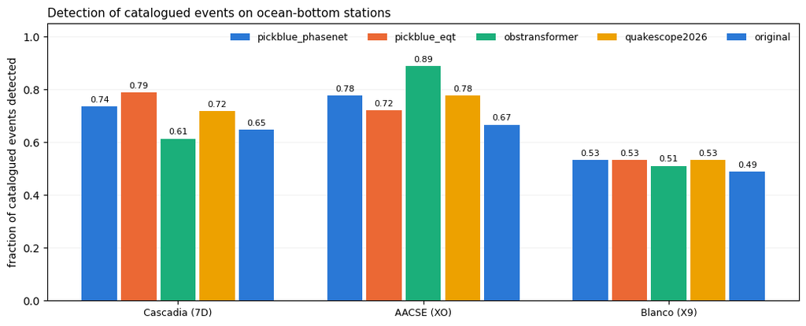

```python
if len(summary):
    labels = [l for l in EXPERIMENTS if l in set(summary.experiment)]
    fig, ax = plt.subplots(figsize=(10.5, 4.3))
    width = 0.8 / max(len(names), 1)
    for i, name in enumerate(names):
        xs, vals = [], []
        for j, lab in enumerate(labels):
            r = summary[(summary.experiment == lab) & (summary.weights == name)]
            if len(r):
                xs.append(j + (i - (len(names) - 1) / 2) * width)
                vals.append(float(r['rate'].iloc[0]))
        ax.bar(xs, vals, width=width * 0.9, color=COLORS[i % len(COLORS)], label=name)
        for x, v in zip(xs, vals):
            ax.text(x, v + 0.015, f'{v:.2f}', ha='center', fontsize=8)
    ax.set_xticks(range(len(labels)))
    ax.set_xticklabels(labels, fontsize=9)
    ax.set_ylabel('fraction of catalogued events detected')
    ax.set_ylim(0, 1.05)
    ax.grid(alpha=0.25, lw=0.5, axis='y')
    ax.set_axisbelow(True)
    ax.legend(frameon=False, fontsize=9, ncol=len(names))
    ax.set_title('Detection of catalogued events on ocean-bottom stations',
                 fontsize=11, loc='left')
    fig.tight_layout()
    plt.show()
```

### Where the picks land relative to the prediction

What matters is that the cluster is **tight and in the same place for every model** — that indicates they are all locking onto the same physical arrival, and that the offset is a property of the prediction rather than of any weight set.

The offset direction is not a clean diagnostic here. A water column and sediments delay the true arrival relative to iasp91, but offshore catalog locations and depths are themselves poorly constrained — many are fixed rather than solved — and that error enters the prediction directly and in either direction. A consistent offset of a second or two says the prediction is biased, not that the picks are wrong.

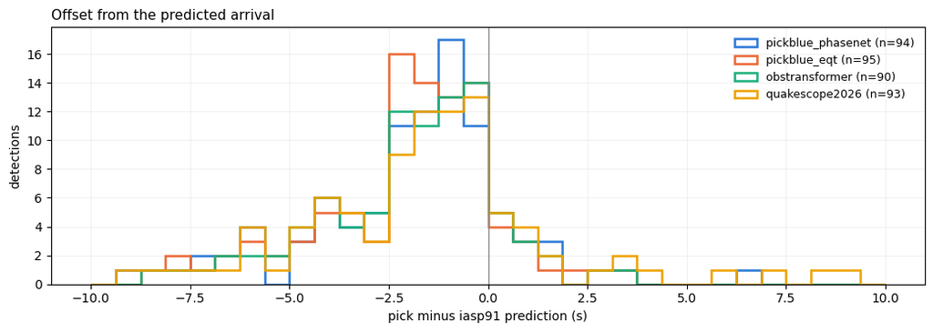

```python
fig, ax = plt.subplots(figsize=(10.5, 3.8))
bins = np.linspace(-TOLERANCE, TOLERANCE, 33)
for name, color in zip(names, COLORS):
    d = hit[hit.weights == name]['dt'].dropna()
    if not len(d):
        continue
    ax.hist(d, bins=bins, histtype='step', lw=1.8, color=color,
            label=f'{name} (n={len(d)})')
ax.axvline(0, color='#8a8a8a', lw=1)
ax.set_xlabel('pick minus iasp91 prediction (s)')
ax.set_ylabel('detections')
ax.set_title('Offset from the predicted arrival', fontsize=11, loc='left')
ax.grid(alpha=0.25, lw=0.5)
ax.legend(frameon=False, fontsize=9)
fig.tight_layout()
plt.show()
```

## 6. Does the hydrophone earn its place?

Re-running `obs` on the same windows with the hydrophone withheld separates the value of the channel from the value of the training.

```python
if ABLATION_MODEL in models:
    rows = []
    for label, entries in examples.items():
      for st, tp, sta, mag, best in entries:
        with_h = st
        without_h = obspy.Stream([tr for tr in st if tr.stats.channel[-1] != 'H'])
        entry = {'experiment': label, 'station': sta, 'M': mag}
        for tag, stream in (('with_H', with_h), ('without_H', without_h)):
            out = models[ABLATION_MODEL].classify(stream, P_threshold=DETECT_FLOOR,
                                         S_threshold=DETECT_FLOOR)
            cand = [float(p.peak_value) for p in out.picks
                    if p.phase == 'P' and abs(p.peak_time - tp) <= TOLERANCE]
            entry[tag] = round(max(cand), 3) if cand else 0.0
        entry['hydrophone_rate'] = next(
            (tr.stats.sampling_rate for tr in st if tr.stats.channel[-1] == 'H'), np.nan)
        rows.append(entry)
    abl = pd.DataFrame(rows)
    if len(abl):
        abl['delta'] = (abl.with_H - abl.without_H).round(3)
        print(f'{len(abl)} detected windows re-run with the hydrophone withheld\n')
        print(abl.groupby(['experiment', 'hydrophone_rate'])[['with_H', 'without_H', 'delta']]
              .agg(['mean', 'count']).round(3).to_string())
        print(f'\nmean change in P confidence when the hydrophone is included: '
              f'{abl.delta.mean():+.4f}')
        worse = int((abl.delta < -0.01).sum()); better = int((abl.delta > 0.01).sum())
        print(f'windows where it helped by >0.01: {better}; hurt by >0.01: {worse}; '
              f'unchanged: {len(abl) - better - worse}')
    else:
        print('no detections captured for the ablation')
```

```
94 detected windows re-run with the hydrophone withheld

                              with_H       without_H        delta
                                mean count      mean count   mean count
experiment    hydrophone_rate
AACSE (XO)    100.0            0.807    28     0.866    28 -0.059    28
Blanco (X9)   10.0             0.855    24     0.876    24 -0.022    24
Cascadia (7D) 40.0             0.772    30     0.693    30  0.079    30
              125.0            0.699    12     0.714    12 -0.015    12

mean change in P confidence when the hydrophone is included: +0.0002
windows where it helped by >0.01: 32; hurt by >0.01: 35; unchanged: 27
```

## 7. Scanning the records

Ten windows per deployment, spread across its stations rather than drawn from one, vertical component, with **every model's pick overlaid** so disagreements are visible at a glance. The dotted line is the iasp91 prediction, which per section 5 carries the catalog's location error and should be read as an approximate marker rather than truth.

What to look for: picks clustering on a visible onset is the model working; picks spread across seconds of an emergent arrival is the hard case that ocean-bottom noise creates; and a pick with nothing visible under it is worth following up.

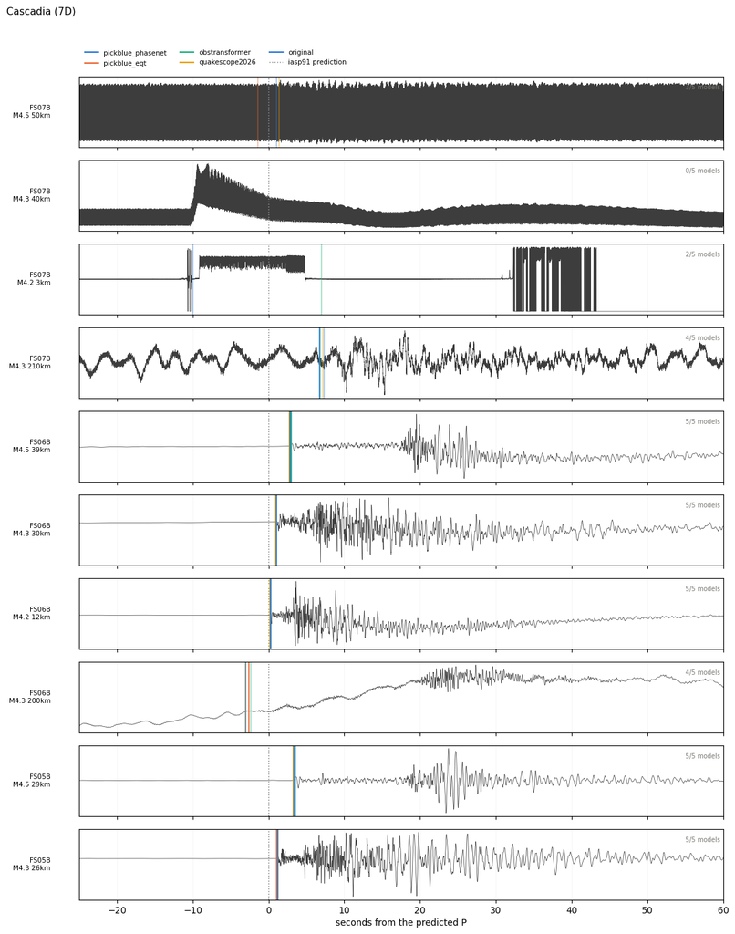

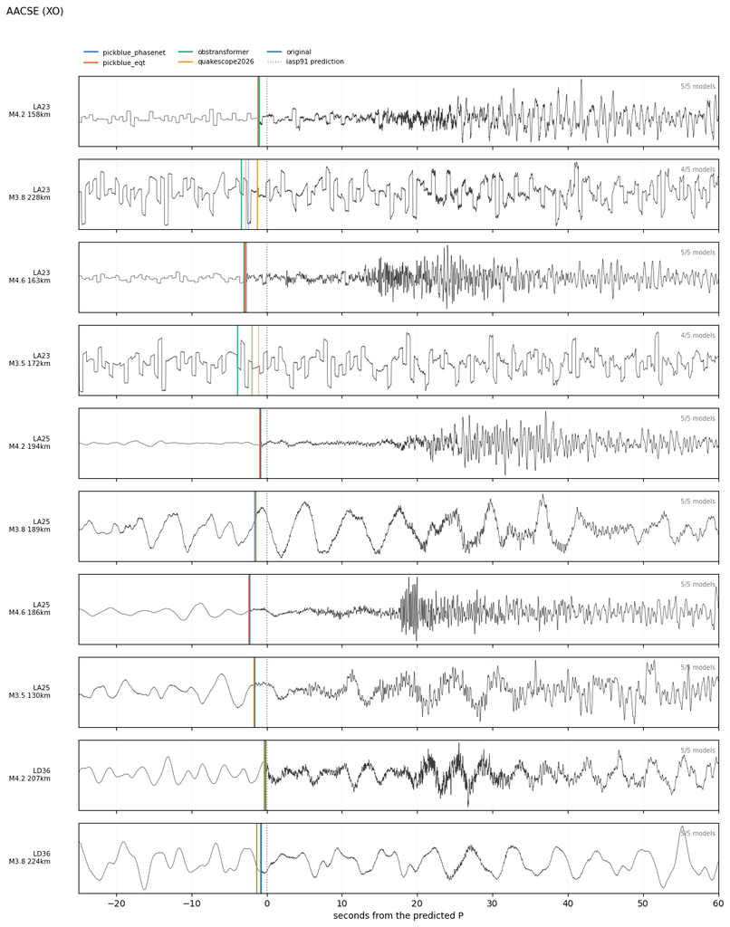

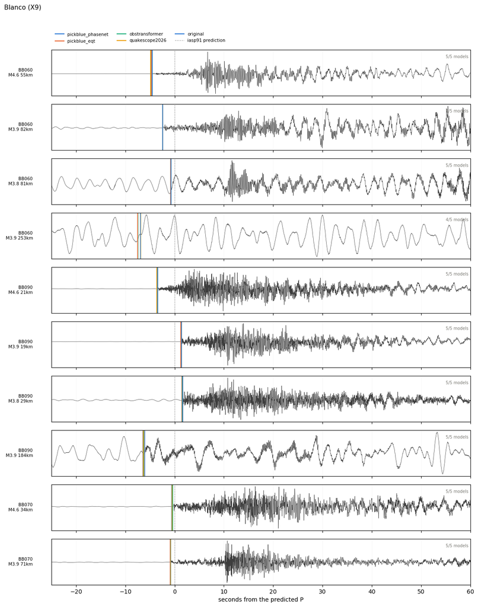

```python
def gallery_figure(label, entries, window=(-25, 60)):
    n = len(entries)
    fig, axes = plt.subplots(n, 1, figsize=(11.5, 1.35 * n + 1.0), sharex=True)
    axes = np.atleast_1d(axes)
    for ax, e in zip(axes, entries):
        tr = e['stream'].select(component='Z')
        if not tr:
            continue
        tr = tr[0]
        t = tr.times(reftime=e['tp'])
        x = tr.data.astype(float)
        peak = np.abs(x).max()
        if peak > 0:
            x = x / peak
        ax.plot(t, x, color='#3d3d3d', lw=0.5)
        ax.axvline(0, color='#8a8a8a', lw=1.1, ls=':')
        for i, name in enumerate(names):
            if name not in e['picks']:
                continue
            dt, conf = e['picks'][name]
            ax.axvline(dt, color=COLORS[i % len(COLORS)], lw=1.5,
                       alpha=0.85 if conf >= REPORT_THRESHOLD else 0.35)
        found = len(e['picks'])
        ax.set_ylabel(f"{e['sta']}\nM{e['mag']:.1f} {e['deg']*111:.0f}km",
                      fontsize=7.5, rotation=0, ha='right', va='center', labelpad=32)
        ax.set_yticks([])
        ax.grid(alpha=0.18, lw=0.4, axis='x')
        ax.text(0.995, 0.82, f'{found}/{len(names)} models',
                transform=ax.transAxes, ha='right', fontsize=7, color='#7a7973')
    handles = [plt.Line2D([], [], color=COLORS[i % len(COLORS)], lw=1.6, label=n)
               for i, n in enumerate(names)]
    handles.append(plt.Line2D([], [], color='#8a8a8a', lw=1.1, ls=':',
                              label='iasp91 prediction'))
    axes[0].legend(handles=handles, fontsize=7.5, frameon=False, ncol=3,
                   loc='lower left', bbox_to_anchor=(0, 1.05))
    axes[-1].set_xlim(*window)
    axes[-1].set_xlabel('seconds from the predicted P')
    fig.suptitle(label, fontsize=11, x=0.01, ha='left', y=0.998)
    fig.tight_layout(rect=[0, 0, 1, 0.985])
    return fig


for label in EXPERIMENTS:
    entries = gallery.get(label) or []
    if not entries:
        continue
    gallery_figure(label, entries[:GALLERY_N])
    plt.show()
```

### One record in full

All four components for a single detected event per deployment, including the hydrophone, at its native sampling rate.

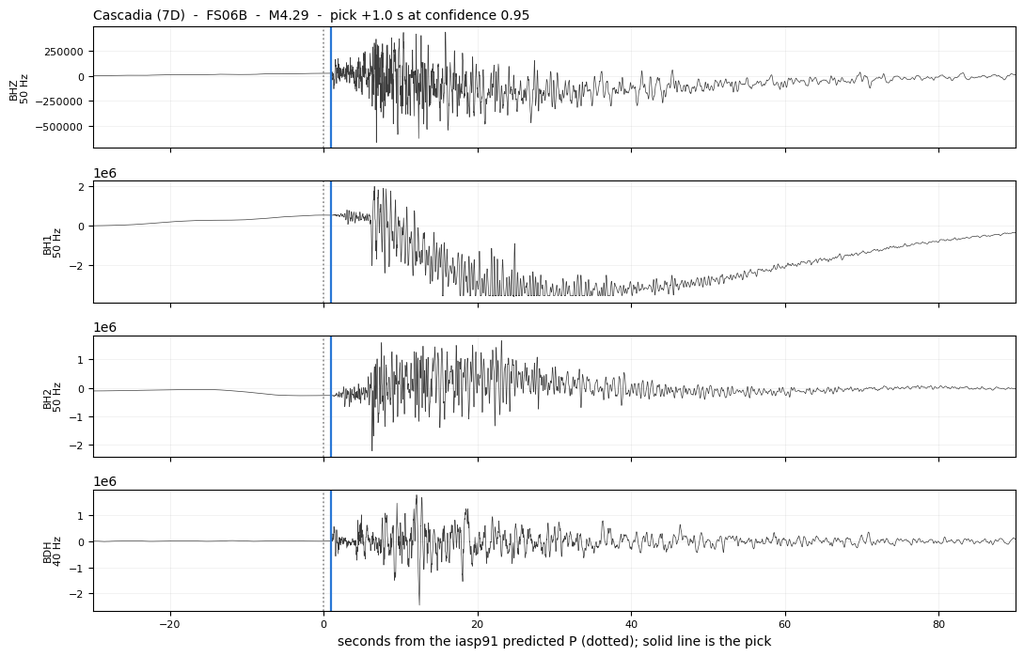

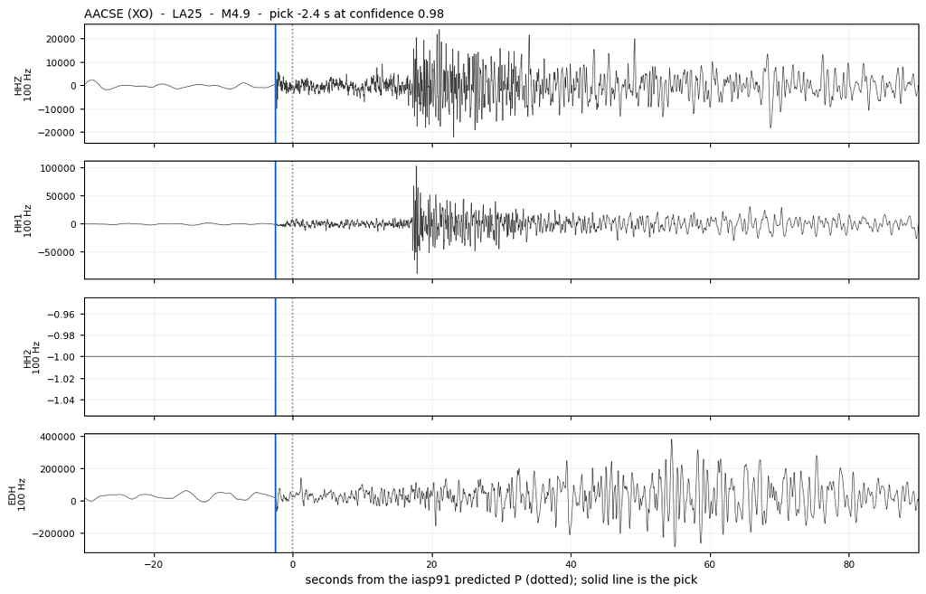

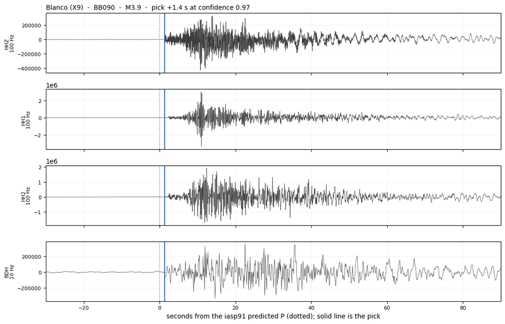

```python
def plot_obs(label, entry, window=(-30, 90)):
    st, tp, sta, mag, best = entry
    order = ['Z', '1', '2', 'H']
    traces = [next((tr for tr in st if tr.stats.channel[-1] == c), None) for c in order]
    traces = [t for t in traces if t is not None]
    fig, axes = plt.subplots(len(traces), 1, figsize=(11, 1.5 * len(traces) + 1.1),
                             sharex=True)
    axes = np.atleast_1d(axes)
    for ax, tr in zip(axes, traces):
        ax.plot(tr.times(reftime=tp), tr.data, color='#3d3d3d', lw=0.5)
        ax.axvline(0, color='#8a8a8a', lw=1.2, ls=':')
        ax.axvline(best[0], color=C_P, lw=1.6)
        ax.set_ylabel(f'{tr.stats.channel}\n{tr.stats.sampling_rate:g} Hz', fontsize=8)
        ax.grid(alpha=0.22, lw=0.5)
        ax.tick_params(labelsize=8)
    axes[-1].set_xlim(*window)
    axes[-1].set_xlabel('seconds from the iasp91 predicted P '
                        '(dotted); solid line is the pick')
    axes[0].set_title(f'{label}  -  {sta}  -  M{mag}  -  '
                      f'pick {best[0]:+.1f} s at confidence {best[1]:.2f}',
                      fontsize=10, loc='left')
    fig.tight_layout()
    return fig


for label in EXPERIMENTS:
    entries = examples.get(label) or []
    if entries:
        plot_obs(label, max(entries, key=lambda e: e[4][1]))
        plt.show()
```

## 8. The campaign's own picks against published arrivals

Everything above scores *models* on windows fetched for the purpose. The `obs` campaign has now run: 6,231 shards over 23 networks, written as Parquet on S3, using one of the weight sets from section 3. That output is what QuakeScope will hand to people, so it is what needs validating, and against something better than a travel-time prediction.

Two published references are obtainable today. Both are compared the way `western_pick_validation.ipynb` compares the western campaign against a re-pick: **match on station, phase and time within a stated tolerance; report what the campaign holds separately from what it found; and never turn the reference's silence into a false positive.** A reference catalogue is not exhaustive, and an OBS deployment's archive is not complete, so an unmatched campaign pick is *unscored*, not wrong.

[output not shown]

The AACSE comparison is the one that matters most: the reference is analyst truth, both sides are picks, and it covers 65 instruments across three instrument types. Axial is a picker-against-picker comparison - the UW picks are automatic - on a very different kind of seismicity, and it is kept because that difference is informative.

### What the campaign ran

Read from the campaign's own run records, never typed in.

```python
import datetime, hashlib, io, json, ssl, tarfile, time, urllib.error, urllib.request
from concurrent.futures import ThreadPoolExecutor
from pathlib import Path

import boto3

BUCKET, REGION, CAMPAIGN = "quakescope-picks-2026", "us-east-2", "obs"
CACHE = Path("obs_benchmark_cache")      # gitignored. Delete it to re-download everything.
CACHE.mkdir(exist_ok=True)
s3 = boto3.client("s3", region_name=REGION)
_pg = s3.get_paginator("list_objects_v2")

TOL_ANALYST = 1.0     # s, against AACSE analyst arrivals (sections 9 and 10)
TOL_AXIAL = 0.5       # s, against Axial picks - sources sit within a few km of the array
PALETTE = COLORS + ["#8e5bd6"]   # a fifth slot, so five models never share a colour

runs, token = [], None
while len(runs) < 300:                        # a sample of the ~6,500 run records
    kw = dict(Bucket=BUCKET, Prefix=f"{CAMPAIGN}/runs/", MaxKeys=150)
    if token:
        kw["ContinuationToken"] = token
    page = s3.list_objects_v2(**kw)
    for o in page.get("Contents", []):
        runs.append(json.loads(s3.get_object(Bucket=BUCKET, Key=o["Key"])["Body"].read()))
    token = page.get("NextContinuationToken")
    if not token:
        break
cfg = pd.DataFrame(runs)
fields = ["model", "weight", "p_threshold", "s_threshold", "components_loaded",
          "seisbench_version", "weight_version"]
print(f"{len(cfg)} run records sampled")
for f in fields:
    print(f"  {f:20s} {cfg[f].value_counts().to_dict()}")
assert all(cfg[f].nunique() == 1 for f in fields), "the obs campaign was not run under one configuration"
PROD = {f: cfg[f].iloc[0] for f in fields}

# The campaign's weight file and the one PickBlue(base="phasenet") loaded in section 3.
repo_w = Path("../sb_catalog/models/v3/phasenet/obs.pt.v1")
cache_w = Path.home() / ".seisbench/models/v3/phasenet/obs.pt.v1"
md5 = {p.name + " (" + tag + ")": hashlib.md5(p.read_bytes()).hexdigest()[:12]
       for tag, p in (("shipped in the image", repo_w), ("seisbench cache", cache_w)) if p.exists()}
print(f"\nThe campaign is PhaseNet/{PROD['weight']} at P={PROD['p_threshold']}, S={PROD['s_threshold']}, "
      f"components {PROD['components_loaded']}, seisbench {PROD['seisbench_version']}.")
print("Weight file md5:", md5)
print("`obs` is the PickBlue PhaseNet weight (component order Z12H). The campaign loads ZNE12 and no\n"
      "hydrophone, so SeisBench zero-fills the H slot - section 6 measured that channel's effect at +0.0002.")
```

```
300 run records sampled
  model                {'PhaseNet': 300}
  weight               {'obs': 300}
  p_threshold          {'0.2': 300}
  s_threshold          {'0.2': 300}
  components_loaded    {'ZNE12': 300}
  seisbench_version    {'0.12.5': 300}
  weight_version       {'1': 300}

The campaign is PhaseNet/obs at P=0.2, S=0.2, components ZNE12, seisbench 0.12.5.
Weight file md5: {'obs.pt.v1 (shipped in the image)': '21e57268fcd9', 'obs.pt.v1 (seisbench cache)': '21e57268fcd9'}
`obs` is the PickBlue PhaseNet weight (component order Z12H). The campaign loads ZNE12 and no
hydrophone, so SeisBench zero-fills the H slot - section 6 measured that channel's effect at +0.0002.
```

### Reference data

Fetched into `obs_benchmark_cache/` beside this notebook and reused on later runs. The Barcheck tables are the SeisBench metadata format: one row per waveform, with the P and S arrival as a sample index into a trace whose start time is given to the microsecond.

```python
ECOMMONS = "https://ecommons.cornell.edu/server/api/core/bitstreams/{}/content"
REFERENCES = {
    "barcheck_obs_readme":  (ECOMMONS.format("77528b48-2397-41c4-8bfc-558a29faa28d"), "AACSE_2018_ReadMe.txt"),
    "barcheck_obs_2018":    (ECOMMONS.format("08969cf9-30ff-4067-8ceb-8f732696d2ff"), "archive_metadata2018.tar.gz"),
    "barcheck_land":        (ECOMMONS.format("20b7a01a-c576-4b44-b8c1-a592ee4d2980"), "archive_AACSE_metadata_land.tar.gz"),
    "uw_axial_phases":      ("http://axial.ocean.washington.edu/ph2dtInputCatalog.dat", "ph2dtInputCatalog.dat"),
    "ldeo_axial_readme":    ("https://axialdd.ldeo.columbia.edu/catalog/README", "Axial.MLDD.README"),
    "ldeo_axial_catalogue": ("https://axialdd.ldeo.columbia.edu/catalog/Axial.MLDD.v202112.2", "Axial.MLDD.v202112.2"),
}


def fetch(url, name):
    dest = CACHE / name
    if dest.exists() and dest.stat().st_size > 0:
        return dest
    try:
        with urllib.request.urlopen(url, timeout=900) as r:
            dest.write_bytes(r.read())
    except urllib.error.URLError as exc:
        if "ldeo.columbia.edu" not in url or "CERTIFICATE" not in str(exc).upper():
            raise
        # The LDEO host serves a chain Python cannot verify. Public catalogue, so accept it.
        with urllib.request.urlopen(url, timeout=900, context=ssl._create_unverified_context()) as r:
            dest.write_bytes(r.read())
    return dest


files = {}
for key, (url, name) in REFERENCES.items():
    t0 = time.time()
    files[key] = fetch(url, name)
    print(f"  {key:22s} {files[key].stat().st_size / 1e6:8.1f} MB  {time.time() - t0:5.1f} s  {name}")

for key, sub in (("barcheck_obs_2018", "barcheck_obs_2018"), ("barcheck_land", "barcheck_land")):
    out = CACHE / sub
    if not out.exists():
        with tarfile.open(files[key]) as tf:
            tf.extractall(out)
print("\nBarcheck readme, first lines:")
print("\n".join(files["barcheck_obs_readme"].read_text().splitlines()[:3]))
print("\nLDEO readme, overview:")
print("\n".join(l for l in files["ldeo_axial_readme"].read_text().splitlines()[18:23]))
```

```
  barcheck_obs_readme         0.0 MB    0.0 s  AACSE_2018_ReadMe.txt
  barcheck_obs_2018           0.7 MB    0.0 s  archive_metadata2018.tar.gz
  barcheck_land               4.0 MB    0.0 s  archive_AACSE_metadata_land.tar.gz
  uw_axial_phases           102.2 MB    0.0 s  ph2dtInputCatalog.dat
  ldeo_axial_readme           0.0 MB    0.0 s  Axial.MLDD.README
  ldeo_axial_catalogue       14.7 MB    0.0 s  Axial.MLDD.v202112.2

Barcheck readme, first lines:
Title:
Dataset: Ocean-bottom P and S arrival waveform dataset from the Alaska Amphibious Community Seismic Experiment, 2018


LDEO readme, overview:

OVERVIEW:
This file includes high-precision hypocenter locations for 144,329
earthquakes recorded between November 4, 2014 and December 31, 2021
by the Ocean Observatories Initiatives (OOI) cabled OBS array. They
```

### The campaign's picks

Every pick object under `obs/picks/network=XO/year=2018/` and `obs/picks/network=OO/`, read once from S3 and cached as Parquet. `XO` 2018 is the only AACSE year the campaign holds - 2019 is recorded complete with nothing read, see `27_obs_literature_benchmark.md` - and `OO` runs from the start of the cabled array in 2014 to the campaign's end of 2025.

```python
def campaign_picks(prefix, name):
    dest = CACHE / name
    if dest.exists():
        return pd.read_parquet(dest)
    keys = [o["Key"] for page in _pg.paginate(Bucket=BUCKET, Prefix=prefix)
            for o in page.get("Contents", [])]

    def read(k):
        return pd.read_parquet(io.BytesIO(s3.get_object(Bucket=BUCKET, Key=k)["Body"].read()))

    with ThreadPoolExecutor(16) as ex:
        frames = list(ex.map(read, keys))
    df = pd.concat(frames, ignore_index=True) if frames else pd.DataFrame()
    df.to_parquet(dest)
    return df


t0 = time.time()
camp_xo = campaign_picks(f"{CAMPAIGN}/picks/network=XO/year=2018/", "campaign_XO_2018.parquet")
camp_oo = campaign_picks(f"{CAMPAIGN}/picks/network=OO/", "campaign_OO.parquet")
print(f"read in {time.time() - t0:.0f} s\n")
for label, df in (("XO 2018", camp_xo), ("OO 2014-2025", camp_oo)):
    print(f"{label:14s} {len(df):>10,} picks  {df.tid.nunique():3d} stations  "
          f"bands {df.cha.value_counts().to_dict()}  P/S {df.pha.value_counts().to_dict()}  "
          f"{df.peak.min():%Y-%m-%d} .. {df.peak.max():%Y-%m-%d}")
print(f"\nconfidence floor in the data: P {camp_xo[camp_xo.pha == 'P'].conf.min():.3f}, "
      f"S {camp_xo[camp_xo.pha == 'S'].conf.min():.3f}  (the campaign wrote everything at or above its thresholds)")
```

```
read in 1 s
```

```
XO 2018         4,750,741 picks   97 stations  bands {'HH': 4750741}  P/S {'P': 2887289, 'S': 1863452}  2018-05-11 .. 2018-12-31
```

```
OO 2014-2025    4,045,124 picks   13 stations  bands {'EH': 2671822, 'HH': 1373302}  P/S {'P': 2993075, 'S': 1052049}  2014-11-04 .. 2026-01-01
```

```
confidence floor in the data: P 0.200, S 0.200  (the campaign wrote everything at or above its thresholds)
```

## 9. AACSE 2018: sixty-five ocean-bottom stations against analyst arrivals

The reference is every P and S arrival the Alaska Earthquake Center's analysts kept for an OBS station, for events within 350 km, May–December 2018. Picks flagged `automatic` in that catalogue were machine-made and not individually reviewed, so the headline is **manual picks only**; the automatic ones are reported alongside because they are a second machine's opinion of the same onsets.

Two numbers are kept apart on purpose:

- **coverage** - does the campaign hold *any* pick for that station on that day? If not, the arrival is not scored. A station-day with no picks at all is one the campaign did not read, not one where the picker found nothing; section 9.5 traces those days back to their shards.
- **recall** - on covered station-days, the fraction of analyst arrivals with a campaign pick of the same phase within 1 s.

One second is deliberately strict. The campaign wrote its picks at millisecond resolution and the analyst times are given to the microsecond, so the tolerance is set by physics rather than bookkeeping: for these paths a second is well under the S–P time and comparable to the width of an emergent OBS onset.

```python
def analyst_arrivals(ref):
    """One row per analyst arrival: station, phase, absolute time, status, and the
    event it belongs to. The Barcheck tables give the arrival as a sample index."""
    ref = ref.copy()
    ref["t0"] = pd.to_datetime(ref.trace_start_time, utc=True).dt.tz_localize(None)
    ref["tid"] = "XO." + ref.station_code.str.strip() + "."
    ref["dist_km"] = locations2degrees(ref.station_latitude, ref.station_longitude,
                                       ref.source_latitude_deg, ref.source_longitude_deg) * 111.19
    keep = ["tid", "pha", "t", "status", "source_id", "source_magnitude", "source_depth_km",
            "trace_region", "trace_instrument_type", "dist_km"]
    out = []
    for pha in ("P", "S"):
        s = ref[ref[f"trace_{pha}_arrival_sample"].notna()].copy()
        s["t"] = s.t0 + pd.to_timedelta(s[f"trace_{pha}_arrival_sample"] / s.trace_sampling_rate_hz, unit="s")
        s["pha"], s["status"] = pha, s[f"trace_{pha}_status"]
        out.append(s[keep])
    return pd.concat(out, ignore_index=True)


def _sec(ts):
    return pd.to_datetime(ts).values.astype("datetime64[ns]").astype("int64") / 1e9


def nearest(ref_t, cand_t, cand_conf):
    """For each reference time, the nearest candidate (candidates sorted): offset and confidence."""
    if len(cand_t) == 0:
        return np.full(len(ref_t), np.nan), np.full(len(ref_t), np.nan)
    i = np.searchsorted(cand_t, ref_t)
    lo, hi = np.clip(i - 1, 0, len(cand_t) - 1), np.clip(i, 0, len(cand_t) - 1)
    j = np.where(np.abs(cand_t[hi] - ref_t) < np.abs(cand_t[lo] - ref_t), hi, lo)
    return cand_t[j] - ref_t, cand_conf[j]


def match_to_campaign(arr, picks, tol):
    """dt = campaign pick minus reference pick, in seconds, for the nearest campaign pick of
    the same phase at the same station; `covered` = the campaign holds picks on that station-day."""
    arr = arr.copy()
    arr["day"] = arr.t.dt.floor("D")
    held = picks.assign(day=picks.peak.dt.floor("D")).groupby(["tid", "day"]).size()
    arr["covered"] = pd.MultiIndex.from_arrays([arr.tid, arr.day]).isin(held.index)
    arr["dt"], arr["conf"] = np.nan, np.nan
    groups = {k: (_sec(g.peak), g.conf.values) for k, g in picks.sort_values("peak").groupby(["tid", "pha"])}
    for (tid, pha), g in arr.groupby(["tid", "pha"]):
        if (tid, pha) in groups:
            dt, conf = nearest(_sec(g.t), *groups[(tid, pha)])
            arr.loc[g.index, "dt"], arr.loc[g.index, "conf"] = dt, conf
    arr["hit"] = arr.dt.abs() <= tol
    return arr


ref_obs = pd.concat([pd.read_csv(f) for f in sorted((CACHE / "barcheck_obs_2018").glob("*.csv"))],
                    ignore_index=True)
ref_land = pd.concat([pd.read_csv(f) for f in sorted((CACHE / "barcheck_land").glob("metadata2018*.csv"))],
                     ignore_index=True)
ref_land = ref_land[ref_land.station_network_code == "XO"]
print(f"Barcheck OBS 2018:  {len(ref_obs):,} station-events, {ref_obs.source_id.nunique():,} events, "
      f"{ref_obs.station_code.nunique()} stations, M {ref_obs.source_magnitude.min():.1f}-{ref_obs.source_magnitude.max():.1f}")
print(f"Barcheck land 2018: {len(ref_land):,} station-events on the {ref_land.station_code.nunique()} XO land stations")

t0 = time.time()
arr_obs = match_to_campaign(analyst_arrivals(ref_obs), camp_xo, TOL_ANALYST)
arr_land = match_to_campaign(analyst_arrivals(ref_land), camp_xo, TOL_ANALYST)
print(f"matched in {time.time() - t0:.1f} s\n")

for label, arr in (("OBS", arr_obs), ("land", arr_land)):
    print(f"{label}: {len(arr):,} analyst arrivals; {arr.covered.mean():.1%} fall on station-days the campaign holds picks for "
          f"({(~arr.covered).sum():,} do not, on {arr[~arr.covered].groupby(['tid', 'day']).ngroups} station-days)")

cov = arr_obs[arr_obs.covered]
print(f"\nRecall within {TOL_ANALYST:g} s on covered station-days, OBS:")
print(cov.groupby(["pha", "status"]).hit.agg(recall="mean", n="size").round(3).to_string())
man = cov[cov.status == "manual"]
man_land = arr_land[arr_land.covered & (arr_land.status == "manual")]
print("\nManual picks, by tolerance (OBS / land):")
tols = (0.25, 0.5, 1.0, 2.0)
tab = pd.DataFrame({f"{t:g} s": [(g.dt.abs() <= t).mean() for _, g in man.groupby("pha")] for t in tols},
                   index=[f"OBS {p}" for p in ("P", "S")])
tab = pd.concat([tab, pd.DataFrame({f"{t:g} s": [(g.dt.abs() <= t).mean() for _, g in man_land.groupby("pha")] for t in tols},
                                   index=[f"land {p}" for p in ("P", "S")])])
print(tab.round(3).to_string())
hits = man[man.hit]
print("\nResidual, campaign minus analyst, on hits (s):")
print(hits.groupby("pha").dt.agg(median="median", q25=lambda x: x.quantile(.25), q75=lambda x: x.quantile(.75), n="size").round(3).to_string())
```

```
Barcheck OBS 2018:  20,828 station-events, 2,598 events, 65 stations, M 0.6-6.1
Barcheck land 2018: 20,710 station-events on the 30 XO land stations
```

```
matched in 6.5 s

OBS: 30,618 analyst arrivals; 95.3% fall on station-days the campaign holds picks for (1,436 do not, on 350 station-days)
land: 31,448 analyst arrivals; 96.2% fall on station-days the campaign holds picks for (1,201 do not, on 169 station-days)

Recall within 1 s on covered station-days, OBS:
               recall      n
pha status
P   automatic   0.980   5413
    manual      0.856   9150
S   automatic   0.910   4047
    manual      0.863  10572

Manual picks, by tolerance (OBS / land):
        0.25 s  0.5 s    1 s    2 s
OBS P    0.730  0.805  0.856  0.882
OBS S    0.589  0.765  0.863  0.904
land P   0.785  0.871  0.906  0.916
land S   0.657  0.797  0.852  0.867

Residual, campaign minus analyst, on hits (s):
     median    q25    q75     n
pha
P     0.018 -0.050  0.091  7834
S     0.041 -0.091  0.209  9126
```

### 9.1 Where the campaign's picks land relative to the analyst's

The land stations run through the same `obs` weight, so they are the control for "is this an ocean-bottom problem or a picker problem". If the two distributions sit in the same place with the same width, the weight set is timing onsets the same way on both.

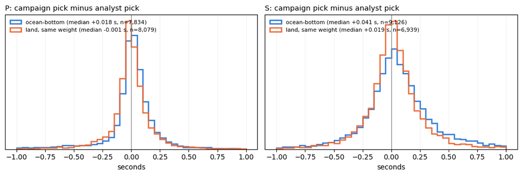

```python
fig, axes = plt.subplots(1, 2, figsize=(10.5, 3.6), sharey=False)
bins = np.arange(-TOL_ANALYST, TOL_ANALYST + 0.05, 0.05)
for ax, pha in zip(axes, ("P", "S")):
    for arr, color, label in ((man, PALETTE[0], "ocean-bottom"), (man_land, PALETTE[1], "land, same weight")):
        d = arr[(arr.pha == pha) & arr.hit].dt
        ax.hist(d, bins=bins, histtype="step", lw=1.8, color=color, density=True,
                label=f"{label} (median {d.median():+.3f} s, n={len(d):,})")
    ax.axvline(0, color="#8a8a8a", lw=1)
    ax.set_title(f"{pha}: campaign pick minus analyst pick", fontsize=10.5, loc="left")
    ax.set_xlabel("seconds"); ax.set_yticks([])
    ax.grid(alpha=0.25, lw=0.5); ax.set_axisbelow(True)
    ax.legend(frameon=False, fontsize=8, loc="upper left")
fig.tight_layout(); plt.show()
```

### 9.2 Recall by instrument, setting, magnitude and distance

Three instrument types went into the water: shielded shallow-shelf instruments, and two makes of unshielded deep-water OBS (WHOI and LDEO). The catalogue's own regions are the shelf, the shelf-slope, and the outer rise seaward of the trench.

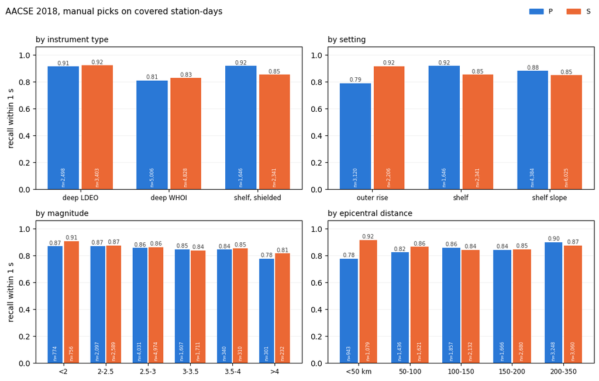

```python
INSTR = {"obs_shallowshelf_shielded": "shelf, shielded", "obs_deep_whoi_unshielded": "deep WHOI",
         "obs_deep_ldeo_unshielded": "deep LDEO"}
REGION = {"shelf_obs": "shelf", "shelf_slope": "shelf slope", "outer_rise": "outer rise"}
m2 = man.assign(instrument=man.trace_instrument_type.map(INSTR), region=man.trace_region.map(REGION),
                magnitude=pd.cut(man.source_magnitude, [0, 2, 2.5, 3, 3.5, 4, 8],
                                 labels=["<2", "2-2.5", "2.5-3", "3-3.5", "3.5-4", ">4"]),
                distance=pd.cut(man.dist_km, [0, 50, 100, 150, 200, 350],
                                labels=["<50 km", "50-100", "100-150", "150-200", "200-350"]))


def breakdown(ax, col, title):
    g = m2.groupby([col, "pha"], observed=True).hit.agg(["mean", "size"]).unstack("pha")
    x = np.arange(len(g)); w = 0.38
    for k, (pha, color) in enumerate((("P", C_P), ("S", C_S))):
        vals = g[("mean", pha)].values
        ax.bar(x + (k - 0.5) * w, vals, width=w * 0.92, color=color, label=pha)
        for xi, v, n in zip(x + (k - 0.5) * w, vals, g[("size", pha)].values):
            ax.text(xi, v + 0.012, f"{v:.2f}", ha="center", fontsize=7.2, color="#3d3d3d")
            ax.text(xi, 0.02, f"n={n:,}", ha="center", fontsize=6, color="white", rotation=90, va="bottom")
    ax.set_xticks(x); ax.set_xticklabels([str(i) for i in g.index], fontsize=8.5)
    ax.set_ylim(0, 1.06); ax.set_title(title, fontsize=10, loc="left")
    ax.grid(alpha=0.25, lw=0.5, axis="y"); ax.set_axisbelow(True)


fig, axes = plt.subplots(2, 2, figsize=(11, 7))
breakdown(axes[0, 0], "instrument", "by instrument type")
breakdown(axes[0, 1], "region", "by setting")
breakdown(axes[1, 0], "magnitude", "by magnitude")
breakdown(axes[1, 1], "distance", "by epicentral distance")
axes[0, 0].set_ylabel(f"recall within {TOL_ANALYST:g} s"); axes[1, 0].set_ylabel(f"recall within {TOL_ANALYST:g} s")
fig.legend(handles=[plt.Rectangle((0, 0), 1, 1, color=C_P, label="P"), plt.Rectangle((0, 0), 1, 1, color=C_S, label="S")],
           frameon=False, fontsize=9, ncol=2, loc="upper right", bbox_to_anchor=(0.99, 0.995))
fig.suptitle("AACSE 2018, manual picks on covered station-days", fontsize=11, x=0.01, ha="left")
fig.tight_layout(rect=[0, 0, 1, 0.97]); plt.show()
```

### 9.3 What the confidence floor buys

The campaign kept everything at or above 0.2 for both phases. Raising the threshold offline is free, and this curve says what it costs: recall of analyst picks as a function of the confidence the campaign attached to the matching pick. The two vertical lines are the campaign's floor and the 0.3 that the rest of this notebook reports at.

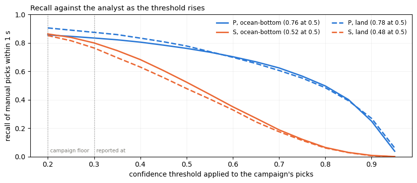

```python
thr = np.arange(0.2, 0.96, 0.05)
fig, ax = plt.subplots(figsize=(8.5, 3.8))
for arr, ls, label in ((man, "-", "ocean-bottom"), (man_land, "--", "land")):
    for pha, color in (("P", C_P), ("S", C_S)):
        g = arr[arr.pha == pha]
        rec = [((g.dt.abs() <= TOL_ANALYST) & (g.conf >= t)).mean() for t in thr]
        ax.plot(thr, rec, ls=ls, lw=2, color=color, label=f"{pha}, {label} ({rec[6]:.2f} at 0.5)")
for t, txt in ((float(PROD["p_threshold"]), "campaign floor"), (REPORT_THRESHOLD, "reported at")):
    ax.axvline(t, color="#8a8a8a", lw=1, ls=":"); ax.text(t + 0.005, 0.03, txt, fontsize=7.5, color="#7a7973")
ax.set_xlabel("confidence threshold applied to the campaign's picks")
ax.set_ylabel(f"recall of manual picks within {TOL_ANALYST:g} s"); ax.set_ylim(0, 1)
ax.grid(alpha=0.25, lw=0.5); ax.set_axisbelow(True); ax.legend(frameon=False, fontsize=8.5, ncol=2)
ax.set_title("Recall against the analyst as the threshold rises", fontsize=10.5, loc="left")
fig.tight_layout(); plt.show()
```

### 9.4 Station by station

The spread between stations is the more useful number than the mean, because it separates a picker that is uniformly mediocre from one that is good almost everywhere and broken somewhere specific. For any station well below the pack, the month-by-month median offset between the campaign's nearest pick and the analyst's tells whether the picks are missing or **mis-timed**: a picker failure gives offsets scattered within a few seconds, whereas an archive whose clock correction differs from the one the analysts worked with gives offsets that move by minutes or hours from month to month.

```
manual P recall per station: median 0.919, quartiles 0.858-0.949, 56 of 64 stations at or above 0.8
```

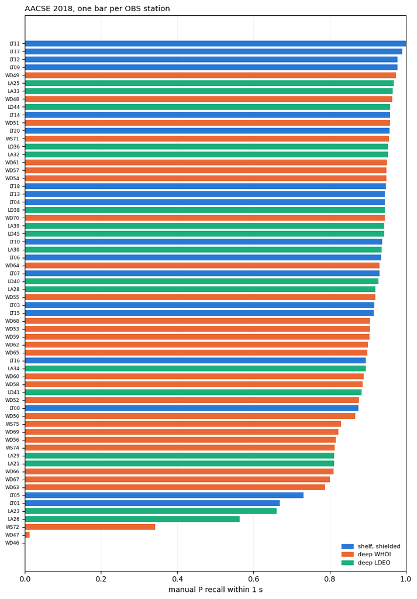

```
6 stations below 0.7. Month-by-month median offset of the nearest campaign P pick (s):
```

```
  XO.WD46.  recall 0.00 over 326 picks; campaign wrote 2,292 picks; within {'1 s': '0.00', '30 s': '0.01', '600 s': '0.08'}
            Jul -173, Aug -2866, Sep -2532, Oct +4954, Nov +5623, Dec -1934
```

```
  XO.WD47.  recall 0.01 over  81 picks; campaign wrote 2,264 picks; within {'1 s': '0.01', '30 s': '0.01', '600 s': '0.02'}
            Jul -25, Aug -1072, Sep -43697, Oct +10474, Nov -2455, Dec -19574
```

```
  XO.WS72.  recall 0.34 over 339 picks; campaign wrote 20,909 picks; within {'1 s': '0.34', '30 s': '0.37', '600 s': '0.50'}
            Jul +0, Aug +0, Sep +102, Oct +419, Nov -6366, Dec -3650
```

```
  XO.LA26.  recall 0.56 over  39 picks; campaign wrote 5,956 picks; within {'1 s': '0.56', '30 s': '0.62', '600 s': '0.72'}
            May +0, Jun +0, Jul -0, Aug +0, Sep +0
  XO.LA23.  recall 0.66 over  53 picks; campaign wrote 50,834 picks; within {'1 s': '0.66', '30 s': '0.66', '600 s': '0.68'}
            May -1726, Jun -0, Jul +0, Aug -0, Sep -0, Dec -0
```

```
  XO.LT01.  recall 0.67 over 151 picks; campaign wrote 161,244 picks; within {'1 s': '0.67', '30 s': '0.70', '600 s': '0.97'}
            May +0, Jun -0, Jul +0, Aug +0, Sep +0, Oct +0, Nov -0, Dec -0
```

```python
per = (man[man.pha == "P"].groupby("tid")
       .agg(recall=("hit", "mean"), n=("hit", "size"), instrument=("trace_instrument_type", "first"))
       .sort_values("recall"))
per["instrument"] = per.instrument.map(INSTR)
print(f"manual P recall per station: median {per.recall.median():.3f}, "
      f"quartiles {per.recall.quantile(.25):.3f}-{per.recall.quantile(.75):.3f}, "
      f"{(per.recall >= 0.8).sum()} of {len(per)} stations at or above 0.8")

fig, ax = plt.subplots(figsize=(8, 0.16 * len(per) + 1.2))
icol = {v: PALETTE[i] for i, v in enumerate(INSTR.values())}
ax.barh(np.arange(len(per)), per.recall, color=[icol[i] for i in per.instrument], height=0.7)
ax.set_yticks(np.arange(len(per))); ax.set_yticklabels([t.split(".")[1] for t in per.index], fontsize=6.5)
ax.set_xlim(0, 1); ax.set_xlabel(f"manual P recall within {TOL_ANALYST:g} s"); ax.grid(alpha=0.25, lw=0.5, axis="x")
ax.set_axisbelow(True)
ax.legend(handles=[plt.Rectangle((0, 0), 1, 1, color=c, label=k) for k, c in icol.items()],
          frameon=False, fontsize=8, loc="lower right")
ax.set_title("AACSE 2018, one bar per OBS station", fontsize=10.5, loc="left")
fig.tight_layout(); plt.show()

weak = per[per.recall < 0.7]
print(f"\n{len(weak)} stations below 0.7. Month-by-month median offset of the nearest campaign P pick (s):")
for tid in weak.index:
    a = man[(man.tid == tid) & (man.pha == "P")]
    monthly = a.groupby(a.t.dt.month).dt.median()
    within = {f"{t:g} s": f"{(a.dt.abs() <= t).mean():.2f}" for t in (1, 30, 600)}
    npicks = (camp_xo.tid == tid).sum()
    print(f"  {tid:9s} recall {weak.loc[tid, 'recall']:.2f} over {weak.loc[tid, 'n']:3d} picks; "
          f"campaign wrote {npicks:,} picks; within {within}")
    print(f"            {', '.join(f'{datetime.date(1900, m, 1):%b} {v:+.0f}' for m, v in monthly.items())}")
```

### 9.5 The station-days the campaign does not hold

An analyst arrival on a station-day with no campaign pick at all is not a miss - a whole day of OBS data never produces zero picks at a 0.2 floor - it is a day the campaign did not read. Each such day belongs to a shard, and each shard left a completion record with the number of station-days it wrote (`picks_record`) against the number it was planned for.

```python
shards_file = CACHE / "obs_shards.jsonl"
if not shards_file.exists():
    s3.download_file(BUCKET, f"{CAMPAIGN}/shards.jsonl", str(shards_file))
shards = [json.loads(l) for l in shards_file.open()]


def _yd(s):
    y, d = s.split(".")
    return datetime.date(int(y), 1, 1) + datetime.timedelta(days=int(d) - 1)


by_station = {}
for sh in shards:
    for t in sh["stations"]:
        by_station.setdefault(t, []).append(sh)

gaps = pd.concat([arr_obs[~arr_obs.covered], arr_land[~arr_land.covered]]).groupby(["tid", "day"]).size().reset_index()
gaps["day"] = gaps.day.dt.date
gaps["shard"] = [next((s["shard_id"] for s in by_station.get(r.tid, []) if _yd(s["start"]) <= r.day < _yd(s["end"])), None)
                 for r in gaps.itertuples()]
print(f"{len(gaps)} uncovered station-days across OBS and land, {gaps.shard.notna().sum()} inside a planned shard, "
      f"{gaps.shard.nunique()} shards")

recs = {}
for sid in gaps.shard.dropna().unique():
    try:
        recs[sid] = json.loads(s3.get_object(Bucket=BUCKET, Key=f"{CAMPAIGN}/complete/{sid}.json")["Body"].read())
    except s3.exceptions.NoSuchKey:
        recs[sid] = {"picks_record": np.nan, "station_days": np.nan, "seconds": np.nan}
tab = pd.DataFrame([dict(shard=k, planned=r.get("station_days"), written=r.get("picks_record"),
                         seconds=r.get("seconds"), uncovered_here=(gaps.shard == k).sum())
                    for k, r in recs.items()]).sort_values("uncovered_here", ascending=False)
tab["written_frac"] = (tab.written / tab.planned).round(2)
print(tab.to_string(index=False))

worst = tab.iloc[0].shard
sh = next(s for s in shards if s["shard_id"] == worst)
days = pd.date_range(_yd(sh["start"]), _yd(sh["end"]) - datetime.timedelta(days=1))
held = set(zip(camp_xo.tid, camp_xo.peak.dt.floor("D")))
grid = pd.DataFrame([[(tid, d) in held for d in days] for tid in sh["stations"]],
                    index=sh["stations"], columns=[f"{d:%m-%d}" for d in days])
print(f"\nshard {worst}: {len(sh['stations'])} stations x {len(days)} days. Stations with picks, per day:")
print(grid.sum(axis=0).to_string())
```

```
519 uncovered station-days across OBS and land, 519 inside a planned shard, 23 shards
```

```
                       shard  planned  written  seconds  uncovered_here  written_frac
2018239-2018259-0cae12e6b282      380      116   1460.7              86          0.31
2018179-2018199-fe9201992769      380      100   1461.1              71          0.26
2018279-2018299-7cfbaa476119      380      220   3483.5              68          0.58
2018359-2019014-be62b51256aa      580       83   1353.9              57          0.14
2018239-2018259-69b557f9b5da      580      340   5003.2              53          0.59
2018199-2018219-a34a2aaa9907      380      300   3653.5              33          0.79
2018219-2018239-a12d8e3d1d88      580       20    317.9              29          0.03
2018299-2018319-bb658359bfb5      580       20    211.3              17          0.03
2018299-2018319-8a78748e7f1a      160       40    493.8              16          0.25
2018339-2018359-744ce5cc5167      140      120   1791.8              13          0.86
2018299-2018319-e90c9487a633      140      120   2033.2              11          0.86
2018319-2018339-5cf7f0be5c8c      140      120   1661.5              11          0.86
2018279-2018299-894ab4397d9a      140      120   2058.2               9          0.86
2018339-2018359-b5a7fb8ff313      140      120   1211.4               9          0.86
2018299-2018319-3971f13e7dda      380      240   2867.8               9          0.63
2018259-2018279-e1875a586b2b      140      120   2106.8               7          0.86
2018239-2018259-0bd6cccdf239      140      113   2068.8               6          0.81
2018359-2019014-c1e9321013a6      140       42    630.3               4          0.30
2018279-2018299-98be32a218f0      140      120   1789.2               3          0.86
2018319-2018339-73dd30eeeb5e      140      120   1678.3               3          0.86
2018339-2018359-2b2d59c14ded      580      580   6712.0               2          1.00
2018279-2018299-7b063bd2e8bd      580      580   8101.3               1          1.00
2018359-2019014-bd47425ffd2b      140       42    466.6               1          0.30
```

```
shard 2018239-2018259-0cae12e6b282: 19 stations x 20 days. Stations with picks, per day:
08-27    16
08-28    16
08-29    16
08-30    16
08-31    16
09-01     0
09-02     0
09-03     0
09-04     0
09-05     0
09-06     0
09-07     4
09-08    19
09-09    19
09-10    19
09-11    19
09-12    19
09-13    19
09-14    19
09-15    19
```

### 9.6 What the campaign has that the analyst does not

The other direction cannot be scored, but it can be sized. On the same station-days, the campaign wrote far more P picks than the analysts kept - which is expected, since the catalogue holds events large enough to locate across the network and an OBS also records everything small and local. The ratio is reported here so nobody reads the recall above as a precision.

```python
cp = camp_xo[camp_xo.pha == "P"].assign(day=camp_xo.peak.dt.floor("D"))
per_day = cp.groupby(["tid", "day"]).agg(at_02=("conf", "size"), at_05=("conf", lambda c: (c >= 0.5).sum()),
                                        at_07=("conf", lambda c: (c >= 0.7).sum()))
analyst_days = arr_obs[arr_obs.pha == "P"].groupby(["tid", "day"]).size().rename("analyst")
j = analyst_days.to_frame().join(per_day, how="inner")
print(f"{len(j):,} OBS station-days with at least one analyst P pick. Median P picks that day:")
print(f"   analyst {j.analyst.median():.0f}   campaign at >=0.2: {j.at_02.median():.0f}   "
      f">=0.5: {j.at_05.median():.0f}   >=0.7: {j.at_07.median():.0f}")
print(f"   campaign-to-analyst ratio at the floor: {j.at_02.sum() / j.analyst.sum():.0f}x; at 0.7: {j.at_07.sum() / j.analyst.sum():.1f}x")
```

```
5,874 OBS station-days with at least one analyst P pick. Median P picks that day:
   analyst 2   campaign at >=0.2: 90   >=0.5: 11   >=0.7: 4
   campaign-to-analyst ratio at the floor: 69x; at 0.7: 3.2x
```

## 10. The five models re-scored against analyst picks

Section 5 scored every model against an iasp91 prediction with a 10 s tolerance, because nothing better existed for OBS stations. For AACSE it now does. The same windows-around-an-arrival procedure runs again on a random sample of the analyst's manual P picks - four components fetched live from EarthScope, every model in section 3 on identical data - and a detection is now a pick within **1 s of the analyst**, not 10 s of a prediction.

Two things this adds over section 9. The campaign only ever ran one weight set, so this is the only place the other four are held to the analyst; and because the campaign's stored pick for each window is also to hand, the stored pick and a live `pickblue_phasenet` pick on the same 3-minute window can be compared directly: a reproduction check across a different data path, the same idea as the western validation, on a window rather than a full day of context.

```python
import warnings
warnings.filterwarnings("ignore", message="Discarding nonzero nanoseconds")

N_RESCORE = 400
rescore_file = CACHE / "rescoring_aacse_2018.parquet"

# The hydrophone code per station, from the inventory - asking for ?DH also returns 1 Hz
# hydrophones, which the OBS model's 0.5 Hz high-pass cannot be applied to.
inv = _es.get_stations(network="XO", starttime=UTCDateTime("2018-05-01"), endtime=UTCDateTime("2019-01-01"),
                       level="channel")
hydro = {}
for s in inv[0]:
    codes = {c.code for c in s if c.code.endswith("DH") and c.code[0] in "HEB"}
    if codes:
        hydro[s.code] = sorted(codes, key=lambda c: "HEB".index(c[0]))[0]

pool = ref_obs[ref_obs.trace_P_status == "manual"].copy()
pool["tP"] = pd.to_datetime(pool.trace_start_time, utc=True) + pd.to_timedelta(pool.trace_P_arrival_sample / pool.trace_sampling_rate_hz, unit="s")
pool["tS"] = pd.to_datetime(pool.trace_start_time, utc=True) + pd.to_timedelta(pool.trace_S_arrival_sample / pool.trace_sampling_rate_hz, unit="s")
pool.loc[pool.trace_S_status != "manual", "tS"] = pd.NaT
sample = pool.sample(min(N_RESCORE, len(pool)), random_state=2026)

stored = {k: (_sec(g.peak), g.conf.values) for k, g in camp_xo.sort_values("peak").groupby(["tid", "pha"])}


def best_pick(picks, pha, tref):
    cand = [(p.peak_time - tref, float(p.peak_value)) for p in picks if p.phase == pha]
    if not cand:
        return np.nan, 0.0
    return min(cand, key=lambda c: abs(c[0]))


if rescore_file.exists():
    rescore = pd.read_parquet(rescore_file)
    print(f"{len(rescore)} rows from cache")
else:
    rows, t_start = [], time.time()
    for i, r in enumerate(sample.itertuples(), 1):
        tp = UTCDateTime(r.tP.to_pydatetime())
        ts = UTCDateTime(r.tS.to_pydatetime()) if pd.notna(r.tS) else None
        chans = "HH?" + (f",{hydro[r.station_code]}" if r.station_code in hydro else "")
        try:
            st = _es.get_waveforms("XO", r.station_code, "*", chans, tp - PRE, tp + POST)
        except Exception:
            continue
        st.merge(fill_value=0)
        if not {"Z", "1", "2"} <= {tr.stats.channel[-1] for tr in st}:
            continue
        st3 = as_three_component(st)
        base = dict(source_id=r.source_id, station=r.station_code, mag=r.source_magnitude,
                    instrument=INSTR.get(r.trace_instrument_type, r.trace_instrument_type),
                    has_h=any(tr.stats.channel[-1] == "H" for tr in st), has_s=ts is not None)
        for name, model in models.items():
            try:
                out = model.classify(st if needs_h[name] else st3, P_threshold=DETECT_FLOOR, S_threshold=DETECT_FLOOR)
            except Exception:
                continue
            dtp, cp_ = best_pick(out.picks, "P", tp)
            dts, cs_ = best_pick(out.picks, "S", ts) if ts else (np.nan, np.nan)
            rows.append(dict(base, weights=name, P_dt=dtp, P_conf=cp_, S_dt=dts, S_conf=cs_))
        tid = f"XO.{r.station_code}."
        rec = dict(base, weights="campaign (stored)")
        for pha, tref in (("P", tp), ("S", ts)):
            if tref is None or (tid, pha) not in stored:
                rec[f"{pha}_dt"], rec[f"{pha}_conf"] = np.nan, np.nan
                continue
            dt, conf = nearest(np.array([tref.timestamp]), *stored[(tid, pha)])
            rec[f"{pha}_dt"], rec[f"{pha}_conf"] = float(dt[0]), float(conf[0])
        rows.append(rec)
        if i % 50 == 0:
            print(f"  {i}/{len(sample)} windows, {time.time() - t_start:.0f} s", flush=True)
    rescore = pd.DataFrame(rows)
    rescore.to_parquet(rescore_file)
    print(f"{rescore.source_id.nunique()} windows scored in {time.time() - t_start:.0f} s")
```

```
2400 rows from cache
```

```
Recall of analyst picks within 1 s, 358 windows, 184 of them with a manual S

                  conf >= 0.3        conf >= 0.2        median P dt (s)
                            P      S           P      S     P_median_dt
weights
pickblue_phasenet       0.695  0.651       0.770  0.737            0.03
pickblue_eqt            0.652  0.569       0.735  0.675            0.04
obstransformer          0.752  0.842       0.805  0.866            0.07
quakescope2026          0.638  0.292       0.742  0.459            0.06
original                0.448  0.478       0.488  0.560            0.10
campaign (stored)       0.802  0.703       0.825  0.809            0.01

The stored campaign row is scored at its own floor only - it holds nothing below it.
```

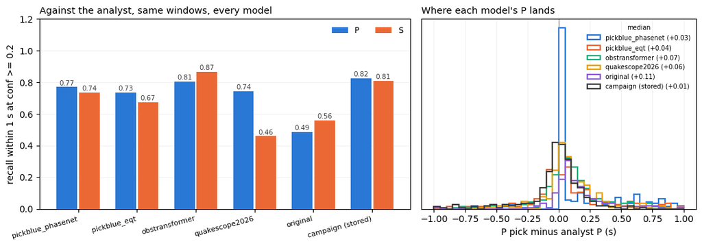

```
Stored campaign pick vs live pickblue_phasenet on the same window, both at conf >= 0.2: 331 windows; |difference| median 0.170 s, within 0.1 s 39.6%, within 1 s 86.4%
The two are not expected to be identical: the campaign picked a full day with SeisBench's overlapping windows and the live run picked 3 minutes, so the window boundaries and the normalisation differ.
```

```python
def recall_table(df, thr, tol=TOL_ANALYST):
    rows = []
    for name, g in df.groupby("weights", sort=False, observed=True):
        p = g
        s = g[g.has_s]
        rows.append(dict(weights=name, windows=len(g),
                         P=((p.P_dt.abs() <= tol) & (p.P_conf >= thr)).mean(),
                         S=((s.S_dt.abs() <= tol) & (s.S_conf >= thr)).mean() if len(s) else np.nan,
                         P_median_dt=p[(p.P_dt.abs() <= tol) & (p.P_conf >= thr)].P_dt.median()))
    return pd.DataFrame(rows).set_index("weights")


order = list(names) + ["campaign (stored)"]
rescore["weights"] = pd.Categorical(rescore.weights, order)
rescore = rescore.sort_values("weights")
floor = float(PROD["p_threshold"])
t_report = recall_table(rescore, REPORT_THRESHOLD)
t_floor = recall_table(rescore, floor)
print(f"Recall of analyst picks within {TOL_ANALYST:g} s, {rescore.source_id.nunique()} windows, "
      f"{int(rescore.groupby('source_id').has_s.first().sum())} of them with a manual S\n")
print(pd.concat({f"conf >= {REPORT_THRESHOLD}": t_report[["P", "S"]], f"conf >= {floor:g}": t_floor[["P", "S"]],
                 "median P dt (s)": t_report[["P_median_dt"]]}, axis=1).round(3).to_string())
print("\nThe stored campaign row is scored at its own floor only - it holds nothing below it.")

fig, axes = plt.subplots(1, 2, figsize=(11, 3.9), gridspec_kw=dict(width_ratios=[1.35, 1]))
ax = axes[0]
x = np.arange(len(order)); w = 0.38
for k, (pha, color) in enumerate((("P", C_P), ("S", C_S))):
    vals = t_floor[pha].values
    ax.bar(x + (k - 0.5) * w, vals, width=w * 0.92, color=color, label=pha)
    for xi, v in zip(x + (k - 0.5) * w, vals):
        ax.text(xi, v + 0.012, f"{v:.2f}", ha="center", fontsize=7.5, color="#3d3d3d")
ax.set_xticks(x); ax.set_xticklabels(order, fontsize=8, rotation=15, ha="right")
ax.set_ylim(0, 1.2); ax.set_ylabel(f"recall within {TOL_ANALYST:g} s at conf >= {floor:g}")
ax.grid(alpha=0.25, lw=0.5, axis="y"); ax.set_axisbelow(True); ax.legend(frameon=False, fontsize=9, loc="upper right", ncol=2)
ax.set_title("Against the analyst, same windows, every model", fontsize=10.5, loc="left")
ax = axes[1]
bins = np.arange(-1, 1.0001, 0.05)
for i, name in enumerate(order):
    d = rescore[(rescore.weights == name) & (rescore.P_conf >= floor)].P_dt
    d = d[d.abs() <= 1]
    ax.hist(d, bins=bins, histtype="step", lw=1.6, color=PALETTE[i % len(PALETTE)] if i < len(PALETTE) else "#3d3d3d",
            label=f"{name} ({d.median():+.2f})")
ax.axvline(0, color="#8a8a8a", lw=1); ax.set_yticks([])
ax.set_xlabel("P pick minus analyst P (s)"); ax.grid(alpha=0.25, lw=0.5); ax.set_axisbelow(True)
ax.legend(frameon=False, fontsize=7, title="median", title_fontsize=7)
ax.set_title("Where each model's P lands", fontsize=10.5, loc="left")
fig.tight_layout(); plt.show()

# stored campaign pick against a live pickblue_phasenet pick on the same window
live = rescore[rescore.weights == "pickblue_phasenet"].set_index(["source_id", "station"])
st_ = rescore[rescore.weights == "campaign (stored)"].set_index(["source_id", "station"])
both = live.join(st_, lsuffix="_live", rsuffix="_stored", how="inner")
both = both[(both.P_conf_live >= floor) & (both.P_conf_stored >= floor)]
agree = (both.P_dt_live - both.P_dt_stored).abs()
print(f"\nStored campaign pick vs live pickblue_phasenet on the same window, both at conf >= {floor:g}: "
      f"{len(both)} windows; |difference| median {agree.median():.3f} s, within 0.1 s {(agree <= 0.1).mean():.1%}, "
      f"within 1 s {(agree <= 1).mean():.1%}")
print("The two are not expected to be identical: the campaign picked a full day with SeisBench's overlapping windows "
      "and the live run picked 3 minutes, so the window boundaries and the normalisation differ.")
```

## 11. Axial Seamount: eleven years against the University of Washington catalogue

This is not the same test as section 9. The reference is a machine, and the seismicity is nothing like Alaska's: sources are inside or under a caldera a few kilometres across, magnitudes are mostly below 0.5, P arrives within a second of the origin, and S follows it by half a second to a second. That is outside the regional-OBS regime the `obs` weights were trained on. The tolerance is 0.5 s, and everything is reported per station so the two instrument bands can be read separately.

```python
def parse_ph2dt(path):
    """HypoDD phase format as served by the UW catalogue: '# YR MO DY HR MN SEC LAT LON DEP MAG
    EH EZ RMS ID' event headers, then 'STA TT WGHT PHA' lines with travel time from the origin."""
    ev, ph, origin, eid = [], [], None, None
    with open(path) as f:
        for line in f:
            p = line.split()
            if line.startswith("#"):
                y, mo, d, h, mi = map(int, p[1:6])
                origin = datetime.datetime(y, mo, d, h, mi) + datetime.timedelta(seconds=float(p[6]))
                eid = int(p[14])
                ev.append((eid, origin, float(p[7]), float(p[8]), float(p[9]), float(p[10])))
            elif len(p) >= 4:
                ph.append((eid, p[0], p[3], float(p[1]), float(p[2])))
    ev = pd.DataFrame(ev, columns=["eid", "origin", "lat", "lon", "dep", "mag"])
    ph = pd.DataFrame(ph, columns=["eid", "sta", "pha", "tt", "wt"]).merge(ev[["eid", "origin", "mag"]], on="eid")
    ph["t"] = ph.origin + pd.to_timedelta(ph.tt, unit="s")
    ph["tid"] = "OO." + ph.sta + "."
    return ev, ph.drop(columns=["origin"])


uw_ev_file, uw_ph_file = CACHE / "uw_axial_events.parquet", CACHE / "uw_axial_picks.parquet"
if uw_ph_file.exists():
    uw_ev, uw_ph = pd.read_parquet(uw_ev_file), pd.read_parquet(uw_ph_file)
else:
    uw_ev, uw_ph = parse_ph2dt(files["uw_axial_phases"])
    uw_ev.to_parquet(uw_ev_file); uw_ph.to_parquet(uw_ph_file)
print(f"UW catalogue as fetched: {len(uw_ev):,} events, {len(uw_ph):,} picks, "
      f"{uw_ev.origin.min():%Y-%m-%d} .. {uw_ev.origin.max():%Y-%m-%d}; magnitude median {uw_ev.mag.median():.1f}")
print(f"UW travel times: P median {uw_ph[uw_ph.pha == 'P'].tt.median():.2f} s, S median {uw_ph[uw_ph.pha == 'S'].tt.median():.2f} s after the origin")

lo, hi = uw_ph.t.min().floor("D"), pd.Timestamp("2026-01-01")
ax_camp = camp_oo[(camp_oo.peak >= lo) & (camp_oo.peak < hi) & camp_oo.tid.str.startswith("OO.AX")]
ax_ref = uw_ph[(uw_ph.t >= lo) & (uw_ph.t < hi)][["tid", "pha", "t", "wt", "mag", "eid"]]
t0 = time.time()
arr_ax = match_to_campaign(ax_ref, ax_camp, TOL_AXIAL)
arr_ax["cha"] = arr_ax.tid.map(ax_camp.groupby("tid").cha.first())
print(f"matched {len(arr_ax):,} UW picks in {time.time() - t0:.0f} s; coverage {arr_ax.covered.mean():.1%}\n")

ndays = (hi - lo).days
rate = pd.DataFrame({
    "band": ax_camp.groupby("tid").cha.first(),
    "campaign P/day": ax_camp[ax_camp.pha == "P"].groupby("tid").size() / ndays,
    "campaign P/day >=0.5": ax_camp[(ax_camp.pha == "P") & (ax_camp.conf >= 0.5)].groupby("tid").size() / ndays,
    "campaign S/day": ax_camp[ax_camp.pha == "S"].groupby("tid").size() / ndays,
    "UW P/day": ax_ref[ax_ref.pha == "P"].groupby("tid").size() / ndays,
    "UW P/day wt>=0.5": ax_ref[(ax_ref.pha == "P") & (ax_ref.wt >= 0.5)].groupby("tid").size() / ndays,
    "UW S/day": ax_ref[ax_ref.pha == "S"].groupby("tid").size() / ndays,
}).round(1)
print("Pick rates, both sides:"); print(rate.to_string())

covx = arr_ax[arr_ax.covered]
print(f"\nRecall of UW picks within {TOL_AXIAL:g} s, per station (covered station-days):")
print(covx.groupby(["tid", "cha", "pha"]).hit.agg(recall="mean", n="size").round(3).unstack("pha").to_string())
print("\nBy UW pick weight, P:")
wp = covx[covx.pha == "P"]
print(wp.groupby(pd.cut(wp.wt, [-0.01, 0.05, 0.3, 0.6, 1.0], labels=["~0", "0.05-0.3", "0.3-0.6", "0.6-1"]), observed=True)
      .hit.agg(recall="mean", n="size").round(3).to_string())
print("\nBy tolerance, P and S, per band:")
print(pd.DataFrame({f"{t:g} s": covx.groupby(["cha", "pha"]).dt.apply(lambda d: (d.abs() <= t).mean()) for t in (0.1, 0.25, 0.5, 1.0)}).round(3).to_string())
print("\nResidual on hits, campaign minus UW (s):")
print(covx[covx.hit].groupby(["cha", "pha"]).dt.agg(median="median", q25=lambda x: x.quantile(.25), q75=lambda x: x.quantile(.75), n="size").round(3).to_string())

# The other direction: how many of the campaign's own P picks does the UW system also have?
rev = []
for tid, g in ax_camp[ax_camp.pha == "P"].groupby("tid"):
    u = np.sort(_sec(ax_ref[(ax_ref.tid == tid) & (ax_ref.pha == "P")].t))
    dt, _ = nearest(_sec(g.sort_values("peak").peak), u, np.zeros(len(u)))
    rev.append(g.sort_values("peak").assign(hit=np.abs(dt) <= TOL_AXIAL))
rev = pd.concat(rev)
print("\nCampaign P picks with a UW P within 0.5 s, by the campaign's confidence:")
print(rev.groupby(["cha", pd.cut(rev.conf, [0.2, 0.3, 0.5, 0.7, 1.0])], observed=True).hit.agg(agree="mean", n="size").round(3).to_string())
```

```
UW catalogue as fetched: 319,076 events, 3,468,987 picks, 2015-01-22 .. 2026-09-07; magnitude median 0.1
```

```
UW travel times: P median 0.58 s, S median 1.19 s after the origin
```

```
matched 3,188,218 UW picks in 3 s; coverage 90.3%
```

```
Pick rates, both sides:
          band  campaign P/day  campaign P/day >=0.5  campaign S/day  UW P/day  UW P/day wt>=0.5  UW S/day
tid
OO.AXAS1.   EH            64.4                  11.5            16.7      56.4              34.7      54.7
OO.AXAS2.   EH            43.4                   7.4            47.2      47.6              26.1      41.1
OO.AXBA1.   HH            21.8                   2.7             2.1       NaN               NaN       NaN
OO.AXCC1.   HH            87.9                  15.6            26.7      53.9              38.4      55.5
OO.AXEC1.   EH            61.8                  10.0            34.5      65.4              47.1      71.2
OO.AXEC2.   HH            36.5                   7.7             4.9      71.4              57.9      71.8
OO.AXEC3.   EH            66.9                  10.9            22.6      68.4              50.9      72.5
OO.AXID1.   EH            56.2                   7.9            34.2      34.4              18.5      33.4

Recall of UW picks within 0.5 s, per station (covered station-days):
```

```
              recall              n
pha                P      S       P       S
tid       cha
OO.AXAS1. EH   0.291  0.013  213759  207824
OO.AXAS2. EH   0.207  0.046  180703  156651
OO.AXCC1. HH   0.342  0.014  193977  206532
OO.AXEC1. EH   0.174  0.053  247264  269959
OO.AXEC2. HH   0.255  0.006  203643  205433
OO.AXEC3. EH   0.192  0.057  259198  274872
OO.AXID1. EH   0.170  0.017  130032  128209

By UW pick weight, P:
          recall       n
wt
~0         0.105  138205
0.05-0.3   0.088  188076
0.3-0.6    0.169  275250
0.6-1      0.309  827045

By tolerance, P and S, per band:
```

```
         0.1 s  0.25 s  0.5 s    1 s
cha pha
EH  P    0.148   0.197  0.208  0.213
    S    0.025   0.035  0.041  0.050
HH  P    0.198   0.282  0.298  0.304
    S    0.002   0.005  0.010  0.022

Residual on hits, campaign minus UW (s):
         median    q25    q75       n
cha pha
EH  P    -0.060 -0.103 -0.030  214541
    S    -0.070 -0.151 -0.020   42146
HH  P    -0.070 -0.115 -0.035  118391
    S    -0.215 -0.359 -0.096    4151
```

```
Campaign P picks with a UW P within 0.5 s, by the campaign's confidence:
                agree       n
cha conf
EH  (0.2, 0.3]  0.097  528355
    (0.3, 0.5]  0.181  451636
    (0.5, 0.7]  0.331  102322
    (0.7, 1.0]  0.534   88078
HH  (0.2, 0.3]  0.096  274414
    (0.3, 0.5]  0.210  205564
    (0.5, 0.7]  0.389   59461
    (0.7, 1.0]  0.566   44673
```

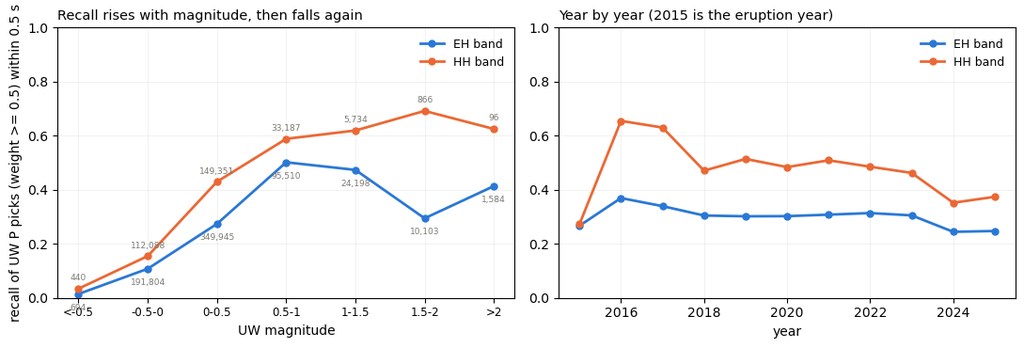

```python
good = covx[(covx.pha == "P") & (covx.wt >= 0.5)]
fig, axes = plt.subplots(1, 2, figsize=(11, 3.8))
ax = axes[0]
mbins = [-3, -0.5, 0, 0.5, 1, 1.5, 2, 5]
mlab = ["<-0.5", "-0.5-0", "0-0.5", "0.5-1", "1-1.5", "1.5-2", ">2"]
for cha, color in (("EH", PALETTE[0]), ("HH", PALETTE[1])):
    g = good[good.cha == cha].groupby(pd.cut(good[good.cha == cha].mag, mbins, labels=mlab), observed=True).hit.agg(["mean", "size"])
    ax.plot(range(len(g)), g["mean"], marker="o", ms=5, lw=2, color=color, label=f"{cha} band")
    for i, (v, n) in enumerate(zip(g["mean"], g["size"])):
        ax.text(i, v + (0.03 if cha == "HH" else -0.06), f"{n:,}", fontsize=6.5, ha="center", color="#7a7973")
ax.set_xticks(range(len(mlab))); ax.set_xticklabels(mlab, fontsize=8.5); ax.set_xlabel("UW magnitude")
ax.set_ylim(0, 1); ax.set_ylabel(f"recall of UW P picks (weight >= 0.5) within {TOL_AXIAL:g} s")
ax.grid(alpha=0.25, lw=0.5); ax.set_axisbelow(True); ax.legend(frameon=False, fontsize=9)
ax.set_title("Recall rises with magnitude, then falls again", fontsize=10.5, loc="left")
ax = axes[1]
for cha, color in (("EH", PALETTE[0]), ("HH", PALETTE[1])):
    g = good[good.cha == cha].groupby(good[good.cha == cha].t.dt.year).hit.agg(["mean", "size"])
    ax.plot(g.index, g["mean"], marker="o", ms=5, lw=2, color=color, label=f"{cha} band")
ax.set_ylim(0, 1); ax.set_xlabel("year"); ax.grid(alpha=0.25, lw=0.5); ax.set_axisbelow(True)
ax.legend(frameon=False, fontsize=9)
ax.set_title("Year by year (2015 is the eruption year)", fontsize=10.5, loc="left")
fig.tight_layout(); plt.show()
```

### 11.1 Event-level detection against the ML-DD catalogue

The LDEO catalogue carries no picks, so it is scored as events: an event counts as detected if the campaign has a P pick on at least three of the seven stations in the three seconds after its origin. The same test on random origin times gives the chance rate.

```python
rows = []
for line in files["ldeo_axial_catalogue"].open():
    p = line.split()
    if len(p) == 15 and p[0].isdigit() and len(p[0]) == 4:
        y, mo, d, h, mi = map(int, p[:5])
        rows.append((datetime.datetime(y, mo, d, h, mi) + datetime.timedelta(seconds=float(p[5])),
                     float(p[6]), float(p[7]), float(p[8]), float(p[13]), int(p[14])))
ldeo = pd.DataFrame(rows, columns=["origin", "lat", "lon", "dep", "mag", "id"])
print(f"LDEO ML-DD: {len(ldeo):,} events, {ldeo.origin.min():%Y-%m-%d} .. {ldeo.origin.max():%Y-%m-%d}, "
      f"magnitude median {ldeo.mag.median():.1f}")

o = _sec(ldeo.origin)
oo_p = camp_oo[(camp_oo.pha == "P") & camp_oo.tid.str.startswith("OO.AX")]


def stations_within(origins, picks, after=(0.05, 3.0)):
    c = np.zeros(len(origins), int)
    for _, g in picks.groupby("tid"):
        ct = np.sort(_sec(g.peak))
        c += np.searchsorted(ct, origins + after[1]) > np.searchsorted(ct, origins + after[0])
    return c


ldeo["n_sta"] = stations_within(o, oo_p)
ldeo["n_sta_05"] = stations_within(o, oo_p[oo_p.conf >= 0.5])
rng = np.random.default_rng(0)
chance = stations_within(rng.uniform(o.min(), o.max(), 20000), oo_p)
print(f"detected (P on >=3 stations within 3 s): {(ldeo.n_sta >= 3).mean():.1%}; with conf >= 0.5: {(ldeo.n_sta_05 >= 3).mean():.1%}; "
      f"on >=1 station: {(ldeo.n_sta >= 1).mean():.1%}. Chance at random times: >=3 {(chance >= 3).mean():.2%}, >=1 {(chance >= 1).mean():.2%}")
print(ldeo.assign(magnitude=pd.cut(ldeo.mag, mbins, labels=mlab)).groupby("magnitude", observed=True)
      .agg(detected=("n_sta", lambda x: (x >= 3).mean()), detected_conf05=("n_sta_05", lambda x: (x >= 3).mean()), n=("n_sta", "size")).round(3).to_string())
```

```
LDEO ML-DD: 144,329 events, 2014-11-04 .. 2021-12-30, magnitude median 0.1
```

```
detected (P on >=3 stations within 3 s): 18.0%; with conf >= 0.5: 7.3%; on >=1 station: 41.3%. Chance at random times: >=3 0.11%, >=1 1.07%
           detected  detected_conf05      n
magnitude
<-0.5         0.007            0.000    284
-0.5-0        0.032            0.001  53735
0-0.5         0.217            0.058  68991
0.5-1         0.500            0.345  13659
1-1.5         0.398            0.306   4588
1.5-2         0.211            0.145   1948
>2            0.474            0.286    325
```

### Export for the consolidated benchmark

Writes the tables above to `docs/benchmark/results/` so that `tutorials/benchmark_summary.ipynb` reads executed output.

```python
# Export the result tables for docs/benchmark/. The consolidated benchmark
# (tutorials/benchmark_summary.ipynb) reads these files rather than numbers
# transcribed from a rendered report, so every figure there traces to an
# executed cell here. Defensive on purpose: a missing table is reported, not fatal.
import datetime as _dt, json as _json
from pathlib import Path as _Path
import seisbench as _sb
_OUT = _Path("../docs/benchmark/results/obs_offshore"); _OUT.mkdir(parents=True, exist_ok=True)
_written = []
def _export(name, obj):
    try:
        (obj.to_csv(_OUT / f"{name}.csv", index=isinstance(obj.index, pd.MultiIndex) or obj.index.name is not None)
         if hasattr(obj, "to_csv") else (_OUT / f"{name}.json").write_text(_json.dumps(obj, indent=1, default=str)))
        _written.append(name)
    except Exception as _exc:
        print(f"{name}: not exported ({type(_exc).__name__}: {_exc})")

_export("detection_vs_iasp91", summary)
_aacse = []
for _label, _arr in (("OBS", arr_obs), ("land", arr_land)):
    _m = _arr[_arr.covered & (_arr.status == "manual")]
    for _pha, _g in _m.groupby("pha"):
        _aacse.append(dict(stations=_label, pha=_pha, n=len(_g), coverage=float(_arr[_arr.pha == _pha].covered.mean()),
                           **{f"recall_{t:g}s": float((_g.dt.abs() <= t).mean()) for t in (0.25, 0.5, 1.0, 2.0)},
                           median_residual_s=float(_g[_g.dt.abs() <= TOL_ANALYST].dt.median())))
_export("aacse_campaign_vs_analyst", pd.DataFrame(_aacse))
_export("aacse_per_station_P", per.reset_index())
_export("aacse_rescoring", pd.concat({f"conf>={REPORT_THRESHOLD}": t_report[["P", "S"]],
                                      f"conf>={floor:g}": t_floor[["P", "S"]],
                                      "median_P_dt_s": t_report[["P_median_dt"]]}, axis=1).reset_index())
_export("axial_pick_rates", rate.reset_index())
_export("axial_recall_per_station", covx.groupby(["tid", "cha", "pha"]).hit.agg(recall="mean", n="size").reset_index())
_export("axial_event_detection_by_magnitude",
        ldeo.assign(magnitude=pd.cut(ldeo.mag, mbins, labels=mlab)).groupby("magnitude", observed=True)
            .agg(detected=("n_sta", lambda x: (x >= 3).mean()), detected_conf05=("n_sta_05", lambda x: (x >= 3).mean()),
                 n=("n_sta", "size")).reset_index())
_meta = dict(notebook="phasenet_obs_offshore_benchmark.ipynb",
             executed=_dt.datetime.now(_dt.timezone.utc).isoformat(timespec="seconds"),
             seisbench=_sb.__version__, campaign=CAMPAIGN, production=PROD,
             tol_analyst_s=TOL_ANALYST, tol_axial_s=TOL_AXIAL, report_threshold=REPORT_THRESHOLD,
             experiments={k: dict(network=v["network"], start=str(v["start"]), end=str(v["end"]),
                                  stations=[s[0] for s in v["stations"]]) for k, v in EXPERIMENTS.items()})
_export("meta", _meta)
print("wrote", ", ".join(_written), "to", _OUT)
```

```
wrote detection_vs_iasp91, aacse_campaign_vs_analyst, aacse_per_station_P, aacse_rescoring, axial_pick_rates, axial_recall_per_station, axial_event_detection_by_magnitude, meta to ../docs/benchmark/results/obs_offshore
```

## Reading the result

**Axial Seamount is where agreement breaks down, and the reason is the seismicity, not the archive.** The campaign and the UW real-time system each write 40–90 P picks a day per station, but only 20–35% of the UW picks have a campaign pick within half a second, and only half of the campaign's most confident picks have a UW counterpart. Recall climbs to about 0.5 for M 0.5–1.5 and collapses below M 0 - which is most of the catalogue. S is essentially unmatched: S–P here is 0.5–0.7 s, and the `obs` weights, trained on regional OBS records at 100 Hz from data the campaign downsampled from 200 Hz, do not resolve it. At the event level the campaign sees 18% of the ML-DD catalogue's 144,000 events on three or more stations, 50% of those between M 0.5 and 1, against a chance rate of 0.1%. The campaign catalogue at Axial is real but much shallower than the dedicated systems produce, and it should not be used to say anything about the sub-M0 seismicity there.

**The comparison in sections 5–7 remains relative, not absolute.** Those sections score against iasp91 with a 10 s tolerance; section 10 shows what that was hiding by scoring the same models against analyst picks at 1 s.

**The land models are being used out of domain on purpose.** That is the measurement: QuakeScope will encounter ocean-bottom data, and the question is what running a land-trained picker over it costs. Renaming the horizontals from `1`/`2` to `N`/`E` is the usual convention and is harmless here, since none of these models uses absolute orientation.

**Thresholds still belong to the weight set.** Section 9.3 gives the curve for `obs`: raising the campaign's floor from 0.2 to 0.5 keeps 76% of the analyst's P picks but only 52% of the S picks. `obs` ships different defaults from the rest, P 0.2 and S 0.1, which is itself a signal that its probabilities are not on the same scale - and the S curve says the campaign's S=0.2 is already above the weight's own default.

**Blanco is still open.** The GJI comparison of EQTransformer, PickBlue and OBSTransformer on the 2012–13 deployment puts its picks behind a request to the corresponding author, and the campaign holds only 2012 of it. Both halves of that arm are a wait, not a computation.